# INM433 Visual Analytics Coursework - Code

#### Hoi Ting Ethel Cheung

```python
import pandas as pd
```

```python
import numpy as np
```

## Data Preparation

```python
#Load and inspect the datasets
olist_customers = pd.read_csv("olist_customers_dataset.csv")
olist_geolocation = pd.read_csv("olist_geolocation_dataset.csv")
olist_order_items = pd.read_csv("olist_order_items_dataset.csv")
olist_order_payments = pd.read_csv("olist_order_payments_dataset.csv")
olist_order_reviews = pd.read_csv("olist_order_reviews_dataset.csv")
olist_orders = pd.read_csv("olist_orders_dataset.csv")
olist_products = pd.read_csv("olist_products_dataset.csv")
olist_sellers = pd.read_csv("olist_sellers_dataset.csv")
product_category_name = pd.read_csv("product_category_name_translation.csv")
```

```python
olist_customers
```

|  | customer_id | customer_unique_id | customer_zip_code_prefix | customer_city | customer_state |
| --- | --- | --- | --- | --- | --- |
| 0 | 06b8999e2fba1a1fbc88172c00ba8bc7 | 861eff4711a542e4b93843c6dd7febb0 | 14409 | franca | SP |
| 1 | 18955e83d337fd6b2def6b18a428ac77 | 290c77bc529b7ac935b93aa66c333dc3 | 9790 | sao bernardo do campo | SP |
| 2 | 4e7b3e00288586ebd08712fdd0374a03 | 060e732b5b29e8181a18229c7b0b2b5e | 1151 | sao paulo | SP |
| 3 | b2b6027bc5c5109e529d4dc6358b12c3 | 259dac757896d24d7702b9acbbff3f3c | 8775 | mogi das cruzes | SP |
| 4 | 4f2d8ab171c80ec8364f7c12e35b23ad | 345ecd01c38d18a9036ed96c73b8d066 | 13056 | campinas | SP |
| ... | ... | ... | ... | ... | ... |
| 99436 | 17ddf5dd5d51696bb3d7c6291687be6f | 1a29b476fee25c95fbafc67c5ac95cf8 | 3937 | sao paulo | SP |
| 99437 | e7b71a9017aa05c9a7fd292d714858e8 | d52a67c98be1cf6a5c84435bd38d095d | 6764 | taboao da serra | SP |
| 99438 | 5e28dfe12db7fb50a4b2f691faecea5e | e9f50caf99f032f0bf3c55141f019d99 | 60115 | fortaleza | CE |
| 99439 | 56b18e2166679b8a959d72dd06da27f9 | 73c2643a0a458b49f58cea58833b192e | 92120 | canoas | RS |
| 99440 | 274fa6071e5e17fe303b9748641082c8 | 84732c5050c01db9b23e19ba39899398 | 6703 | cotia | SP |

99441 rows × 5 columns

```python
olist_geolocation
```

|  | customer_zip_code_prefix | geolocation_lat | geolocation_lng | geolocation_city | geolocation_state |
| --- | --- | --- | --- | --- | --- |
| 0 | 1037 | -23.545621 | -46.639292 | sao paulo | SP |
| 1 | 1046 | -23.546081 | -46.644820 | sao paulo | SP |
| 2 | 1046 | -23.546129 | -46.642951 | sao paulo | SP |
| 3 | 1041 | -23.544392 | -46.639499 | sao paulo | SP |
| 4 | 1035 | -23.541578 | -46.641607 | sao paulo | SP |
| ... | ... | ... | ... | ... | ... |
| 1000158 | 99950 | -28.068639 | -52.010705 | tapejara | RS |
| 1000159 | 99900 | -27.877125 | -52.224882 | getulio vargas | RS |
| 1000160 | 99950 | -28.071855 | -52.014716 | tapejara | RS |
| 1000161 | 99980 | -28.388932 | -51.846871 | david canabarro | RS |
| 1000162 | 99950 | -28.070104 | -52.018658 | tapejara | RS |

1000163 rows × 5 columns

```python
olist_order_items
```

|  | order_id | order_item_id | product_id | seller_id | shipping_limit_date | price | freight_value |
| --- | --- | --- | --- | --- | --- | --- | --- |
| 0 | 00010242fe8c5a6d1ba2dd792cb16214 | 1 | 4244733e06e7ecb4970a6e2683c13e61 | 48436dade18ac8b2bce089ec2a041202 | 2017-09-19 09:45:35 | 58.90 | 13.29 |
| 1 | 00018f77f2f0320c557190d7a144bdd3 | 1 | e5f2d52b802189ee658865ca93d83a8f | dd7ddc04e1b6c2c614352b383efe2d36 | 2017-05-03 11:05:13 | 239.90 | 19.93 |
| 2 | 000229ec398224ef6ca0657da4fc703e | 1 | c777355d18b72b67abbeef9df44fd0fd | 5b51032eddd242adc84c38acab88f23d | 2018-01-18 14:48:30 | 199.00 | 17.87 |
| 3 | 00024acbcdf0a6daa1e931b038114c75 | 1 | 7634da152a4610f1595efa32f14722fc | 9d7a1d34a5052409006425275ba1c2b4 | 2018-08-15 10:10:18 | 12.99 | 12.79 |
| 4 | 00042b26cf59d7ce69dfabb4e55b4fd9 | 1 | ac6c3623068f30de03045865e4e10089 | df560393f3a51e74553ab94004ba5c87 | 2017-02-13 13:57:51 | 199.90 | 18.14 |
| ... | ... | ... | ... | ... | ... | ... | ... |
| 112645 | fffc94f6ce00a00581880bf54a75a037 | 1 | 4aa6014eceb682077f9dc4bffebc05b0 | b8bc237ba3788b23da09c0f1f3a3288c | 2018-05-02 04:11:01 | 299.99 | 43.41 |
| 112646 | fffcd46ef2263f404302a634eb57f7eb | 1 | 32e07fd915822b0765e448c4dd74c828 | f3c38ab652836d21de61fb8314b69182 | 2018-07-20 04:31:48 | 350.00 | 36.53 |
| 112647 | fffce4705a9662cd70adb13d4a31832d | 1 | 72a30483855e2eafc67aee5dc2560482 | c3cfdc648177fdbbbb35635a37472c53 | 2017-10-30 17:14:25 | 99.90 | 16.95 |
| 112648 | fffe18544ffabc95dfada21779c9644f | 1 | 9c422a519119dcad7575db5af1ba540e | 2b3e4a2a3ea8e01938cabda2a3e5cc79 | 2017-08-21 00:04:32 | 55.99 | 8.72 |
| 112649 | fffe41c64501cc87c801fd61db3f6244 | 1 | 350688d9dc1e75ff97be326363655e01 | f7ccf836d21b2fb1de37564105216cc1 | 2018-06-12 17:10:13 | 43.00 | 12.79 |

112650 rows × 7 columns

```python
olist_order_payments
```

|  | order_id | payment_sequential | payment_type | payment_installments | payment_value |
| --- | --- | --- | --- | --- | --- |
| 0 | b81ef226f3fe1789b1e8b2acac839d17 | 1 | credit_card | 8 | 99.33 |
| 1 | a9810da82917af2d9aefd1278f1dcfa0 | 1 | credit_card | 1 | 24.39 |
| 2 | 25e8ea4e93396b6fa0d3dd708e76c1bd | 1 | credit_card | 1 | 65.71 |
| 3 | ba78997921bbcdc1373bb41e913ab953 | 1 | credit_card | 8 | 107.78 |
| 4 | 42fdf880ba16b47b59251dd489d4441a | 1 | credit_card | 2 | 128.45 |
| ... | ... | ... | ... | ... | ... |
| 103881 | 0406037ad97740d563a178ecc7a2075c | 1 | boleto | 1 | 363.31 |
| 103882 | 7b905861d7c825891d6347454ea7863f | 1 | credit_card | 2 | 96.80 |
| 103883 | 32609bbb3dd69b3c066a6860554a77bf | 1 | credit_card | 1 | 47.77 |
| 103884 | b8b61059626efa996a60be9bb9320e10 | 1 | credit_card | 5 | 369.54 |
| 103885 | 28bbae6599b09d39ca406b747b6632b1 | 1 | boleto | 1 | 191.58 |

103886 rows × 5 columns

```python
olist_order_reviews
```

|  | review_id | order_id | review_score | review_comment_title | review_comment_message | review_creation_date | review_answer_timestamp |
| --- | --- | --- | --- | --- | --- | --- | --- |
| 0 | 7bc2406110b926393aa56f80a40eba40 | 73fc7af87114b39712e6da79b0a377eb | 4 | NaN | NaN | 2018-01-18 00:00:00 | 2018-01-18 21:46:59 |
| 1 | 80e641a11e56f04c1ad469d5645fdfde | a548910a1c6147796b98fdf73dbeba33 | 5 | NaN | NaN | 2018-03-10 00:00:00 | 2018-03-11 03:05:13 |
| 2 | 228ce5500dc1d8e020d8d1322874b6f0 | f9e4b658b201a9f2ecdecbb34bed034b | 5 | NaN | NaN | 2018-02-17 00:00:00 | 2018-02-18 14:36:24 |
| 3 | e64fb393e7b32834bb789ff8bb30750e | 658677c97b385a9be170737859d3511b | 5 | NaN | Recebi bem antes do prazo estipulado. | 2017-04-21 00:00:00 | 2017-04-21 22:02:06 |
| 4 | f7c4243c7fe1938f181bec41a392bdeb | 8e6bfb81e283fa7e4f11123a3fb894f1 | 5 | NaN | Parabéns lojas lannister adorei comprar pela I... | 2018-03-01 00:00:00 | 2018-03-02 10:26:53 |
| ... | ... | ... | ... | ... | ... | ... | ... |
| 99995 | f3897127253a9592a73be9bdfdf4ed7a | 22ec9f0669f784db00fa86d035cf8602 | 5 | NaN | NaN | 2017-12-09 00:00:00 | 2017-12-11 20:06:42 |
| 99996 | b3de70c89b1510c4cd3d0649fd302472 | 55d4004744368f5571d1f590031933e4 | 5 | NaN | Excelente mochila, entrega super rápida. Super... | 2018-03-22 00:00:00 | 2018-03-23 09:10:43 |
| 99997 | 1adeb9d84d72fe4e337617733eb85149 | 7725825d039fc1f0ceb7635e3f7d9206 | 4 | NaN | NaN | 2018-07-01 00:00:00 | 2018-07-02 12:59:13 |
| 99998 | be360f18f5df1e0541061c87021e6d93 | f8bd3f2000c28c5342fedeb5e50f2e75 | 1 | NaN | Solicitei a compra de uma capa de retrovisor c... | 2017-12-15 00:00:00 | 2017-12-16 01:29:43 |
| 99999 | efe49f1d6f951dd88b51e6ccd4cc548f | 90531360ecb1eec2a1fbb265a0db0508 | 1 | NaN | meu produto chegou e ja tenho que devolver, po... | 2017-07-03 00:00:00 | 2017-07-03 21:01:49 |

100000 rows × 7 columns

```python
olist_orders
```

|  | order_id | customer_id | order_status | order_purchase_timestamp | order_approved_at | order_delivered_carrier_date | order_delivered_customer_date | order_estimated_delivery_date |
| --- | --- | --- | --- | --- | --- | --- | --- | --- |
| 0 | e481f51cbdc54678b7cc49136f2d6af7 | 9ef432eb6251297304e76186b10a928d | delivered | 2017-10-02 10:56:33 | 2017-10-02 11:07:15 | 2017-10-04 19:55:00 | 2017-10-10 21:25:13 | 2017-10-18 00:00:00 |
| 1 | 53cdb2fc8bc7dce0b6741e2150273451 | b0830fb4747a6c6d20dea0b8c802d7ef | delivered | 2018-07-24 20:41:37 | 2018-07-26 03:24:27 | 2018-07-26 14:31:00 | 2018-08-07 15:27:45 | 2018-08-13 00:00:00 |
| 2 | 47770eb9100c2d0c44946d9cf07ec65d | 41ce2a54c0b03bf3443c3d931a367089 | delivered | 2018-08-08 08:38:49 | 2018-08-08 08:55:23 | 2018-08-08 13:50:00 | 2018-08-17 18:06:29 | 2018-09-04 00:00:00 |
| 3 | 949d5b44dbf5de918fe9c16f97b45f8a | f88197465ea7920adcdbec7375364d82 | delivered | 2017-11-18 19:28:06 | 2017-11-18 19:45:59 | 2017-11-22 13:39:59 | 2017-12-02 00:28:42 | 2017-12-15 00:00:00 |
| 4 | ad21c59c0840e6cb83a9ceb5573f8159 | 8ab97904e6daea8866dbdbc4fb7aad2c | delivered | 2018-02-13 21:18:39 | 2018-02-13 22:20:29 | 2018-02-14 19:46:34 | 2018-02-16 18:17:02 | 2018-02-26 00:00:00 |
| ... | ... | ... | ... | ... | ... | ... | ... | ... |
| 99436 | 9c5dedf39a927c1b2549525ed64a053c | 39bd1228ee8140590ac3aca26f2dfe00 | delivered | 2017-03-09 09:54:05 | 2017-03-09 09:54:05 | 2017-03-10 11:18:03 | 2017-03-17 15:08:01 | 2017-03-28 00:00:00 |
| 99437 | 63943bddc261676b46f01ca7ac2f7bd8 | 1fca14ff2861355f6e5f14306ff977a7 | delivered | 2018-02-06 12:58:58 | 2018-02-06 13:10:37 | 2018-02-07 23:22:42 | 2018-02-28 17:37:56 | 2018-03-02 00:00:00 |
| 99438 | 83c1379a015df1e13d02aae0204711ab | 1aa71eb042121263aafbe80c1b562c9c | delivered | 2017-08-27 14:46:43 | 2017-08-27 15:04:16 | 2017-08-28 20:52:26 | 2017-09-21 11:24:17 | 2017-09-27 00:00:00 |
| 99439 | 11c177c8e97725db2631073c19f07b62 | b331b74b18dc79bcdf6532d51e1637c1 | delivered | 2018-01-08 21:28:27 | 2018-01-08 21:36:21 | 2018-01-12 15:35:03 | 2018-01-25 23:32:54 | 2018-02-15 00:00:00 |
| 99440 | 66dea50a8b16d9b4dee7af250b4be1a5 | edb027a75a1449115f6b43211ae02a24 | delivered | 2018-03-08 20:57:30 | 2018-03-09 11:20:28 | 2018-03-09 22:11:59 | 2018-03-16 13:08:30 | 2018-04-03 00:00:00 |

99441 rows × 8 columns

```python
olist_products
```

|  | product_id | product_category_name | product_name_lenght | product_description_lenght | product_photos_qty | product_weight_g | product_length_cm | product_height_cm | product_width_cm |
| --- | --- | --- | --- | --- | --- | --- | --- | --- | --- |
| 0 | 1e9e8ef04dbcff4541ed26657ea517e5 | perfumaria | 40.0 | 287.0 | 1.0 | 225.0 | 16.0 | 10.0 | 14.0 |
| 1 | 3aa071139cb16b67ca9e5dea641aaa2f | artes | 44.0 | 276.0 | 1.0 | 1000.0 | 30.0 | 18.0 | 20.0 |
| 2 | 96bd76ec8810374ed1b65e291975717f | esporte_lazer | 46.0 | 250.0 | 1.0 | 154.0 | 18.0 | 9.0 | 15.0 |
| 3 | cef67bcfe19066a932b7673e239eb23d | bebes | 27.0 | 261.0 | 1.0 | 371.0 | 26.0 | 4.0 | 26.0 |
| 4 | 9dc1a7de274444849c219cff195d0b71 | utilidades_domesticas | 37.0 | 402.0 | 4.0 | 625.0 | 20.0 | 17.0 | 13.0 |
| ... | ... | ... | ... | ... | ... | ... | ... | ... | ... |
| 32946 | a0b7d5a992ccda646f2d34e418fff5a0 | moveis_decoracao | 45.0 | 67.0 | 2.0 | 12300.0 | 40.0 | 40.0 | 40.0 |
| 32947 | bf4538d88321d0fd4412a93c974510e6 | construcao_ferramentas_iluminacao | 41.0 | 971.0 | 1.0 | 1700.0 | 16.0 | 19.0 | 16.0 |
| 32948 | 9a7c6041fa9592d9d9ef6cfe62a71f8c | cama_mesa_banho | 50.0 | 799.0 | 1.0 | 1400.0 | 27.0 | 7.0 | 27.0 |
| 32949 | 83808703fc0706a22e264b9d75f04a2e | informatica_acessorios | 60.0 | 156.0 | 2.0 | 700.0 | 31.0 | 13.0 | 20.0 |
| 32950 | 106392145fca363410d287a815be6de4 | cama_mesa_banho | 58.0 | 309.0 | 1.0 | 2083.0 | 12.0 | 2.0 | 7.0 |

32951 rows × 9 columns

```python
olist_sellers
```

|  | seller_id | seller_zip_code_prefix | seller_city | seller_state |
| --- | --- | --- | --- | --- |
| 0 | 3442f8959a84dea7ee197c632cb2df15 | 13023 | campinas | SP |
| 1 | d1b65fc7debc3361ea86b5f14c68d2e2 | 13844 | mogi guacu | SP |
| 2 | ce3ad9de960102d0677a81f5d0bb7b2d | 20031 | rio de janeiro | RJ |
| 3 | c0f3eea2e14555b6faeea3dd58c1b1c3 | 4195 | sao paulo | SP |
| 4 | 51a04a8a6bdcb23deccc82b0b80742cf | 12914 | braganca paulista | SP |
| ... | ... | ... | ... | ... |
| 3090 | 98dddbc4601dd4443ca174359b237166 | 87111 | sarandi | PR |
| 3091 | f8201cab383e484733266d1906e2fdfa | 88137 | palhoca | SC |
| 3092 | 74871d19219c7d518d0090283e03c137 | 4650 | sao paulo | SP |
| 3093 | e603cf3fec55f8697c9059638d6c8eb5 | 96080 | pelotas | RS |
| 3094 | 9e25199f6ef7e7c347120ff175652c3b | 12051 | taubate | SP |

3095 rows × 4 columns

```python
product_category_name
```

|  | product_category_name | product_category_name_english |
| --- | --- | --- |
| 0 | beleza_saude | health_beauty |
| 1 | informatica_acessorios | computers_accessories |
| 2 | automotivo | auto |
| 3 | cama_mesa_banho | bed_bath_table |
| 4 | moveis_decoracao | furniture_decor |
| ... | ... | ... |
| 66 | flores | flowers |
| 67 | artes_e_artesanato | arts_and_craftmanship |
| 68 | fraldas_higiene | diapers_and_hygiene |
| 69 | fashion_roupa_infanto_juvenil | fashion_childrens_clothes |
| 70 | seguros_e_servicos | security_and_services |

71 rows × 2 columns

```python
olist_products_en = olist_products.merge(product_category_name, on='product_category_name', how='left')
olist_products_en
```

|  | product_id | product_category_name | product_name_lenght | product_description_lenght | product_photos_qty | product_weight_g | product_length_cm | product_height_cm | product_width_cm | product_category_name_english |
| --- | --- | --- | --- | --- | --- | --- | --- | --- | --- | --- |
| 0 | 1e9e8ef04dbcff4541ed26657ea517e5 | perfumaria | 40.0 | 287.0 | 1.0 | 225.0 | 16.0 | 10.0 | 14.0 | perfumery |
| 1 | 3aa071139cb16b67ca9e5dea641aaa2f | artes | 44.0 | 276.0 | 1.0 | 1000.0 | 30.0 | 18.0 | 20.0 | art |
| 2 | 96bd76ec8810374ed1b65e291975717f | esporte_lazer | 46.0 | 250.0 | 1.0 | 154.0 | 18.0 | 9.0 | 15.0 | sports_leisure |
| 3 | cef67bcfe19066a932b7673e239eb23d | bebes | 27.0 | 261.0 | 1.0 | 371.0 | 26.0 | 4.0 | 26.0 | baby |
| 4 | 9dc1a7de274444849c219cff195d0b71 | utilidades_domesticas | 37.0 | 402.0 | 4.0 | 625.0 | 20.0 | 17.0 | 13.0 | housewares |
| ... | ... | ... | ... | ... | ... | ... | ... | ... | ... | ... |
| 32946 | a0b7d5a992ccda646f2d34e418fff5a0 | moveis_decoracao | 45.0 | 67.0 | 2.0 | 12300.0 | 40.0 | 40.0 | 40.0 | furniture_decor |
| 32947 | bf4538d88321d0fd4412a93c974510e6 | construcao_ferramentas_iluminacao | 41.0 | 971.0 | 1.0 | 1700.0 | 16.0 | 19.0 | 16.0 | construction_tools_lights |
| 32948 | 9a7c6041fa9592d9d9ef6cfe62a71f8c | cama_mesa_banho | 50.0 | 799.0 | 1.0 | 1400.0 | 27.0 | 7.0 | 27.0 | bed_bath_table |
| 32949 | 83808703fc0706a22e264b9d75f04a2e | informatica_acessorios | 60.0 | 156.0 | 2.0 | 700.0 | 31.0 | 13.0 | 20.0 | computers_accessories |
| 32950 | 106392145fca363410d287a815be6de4 | cama_mesa_banho | 58.0 | 309.0 | 1.0 | 2083.0 | 12.0 | 2.0 | 7.0 | bed_bath_table |

32951 rows × 10 columns

```python
olist_orders_merge = olist_orders.merge(olist_order_items, on='order_id', how='left')
olist_orders_merge
```

|  | order_id | customer_id | order_status | order_purchase_timestamp | order_approved_at | order_delivered_carrier_date | order_delivered_customer_date | order_estimated_delivery_date | order_item_id | product_id | seller_id | shipping_limit_date | price | freight_value |
| --- | --- | --- | --- | --- | --- | --- | --- | --- | --- | --- | --- | --- | --- | --- |
| 0 | e481f51cbdc54678b7cc49136f2d6af7 | 9ef432eb6251297304e76186b10a928d | delivered | 2017-10-02 10:56:33 | 2017-10-02 11:07:15 | 2017-10-04 19:55:00 | 2017-10-10 21:25:13 | 2017-10-18 00:00:00 | 1.0 | 87285b34884572647811a353c7ac498a | 3504c0cb71d7fa48d967e0e4c94d59d9 | 2017-10-06 11:07:15 | 29.99 | 8.72 |
| 1 | 53cdb2fc8bc7dce0b6741e2150273451 | b0830fb4747a6c6d20dea0b8c802d7ef | delivered | 2018-07-24 20:41:37 | 2018-07-26 03:24:27 | 2018-07-26 14:31:00 | 2018-08-07 15:27:45 | 2018-08-13 00:00:00 | 1.0 | 595fac2a385ac33a80bd5114aec74eb8 | 289cdb325fb7e7f891c38608bf9e0962 | 2018-07-30 03:24:27 | 118.70 | 22.76 |
| 2 | 47770eb9100c2d0c44946d9cf07ec65d | 41ce2a54c0b03bf3443c3d931a367089 | delivered | 2018-08-08 08:38:49 | 2018-08-08 08:55:23 | 2018-08-08 13:50:00 | 2018-08-17 18:06:29 | 2018-09-04 00:00:00 | 1.0 | aa4383b373c6aca5d8797843e5594415 | 4869f7a5dfa277a7dca6462dcf3b52b2 | 2018-08-13 08:55:23 | 159.90 | 19.22 |
| 3 | 949d5b44dbf5de918fe9c16f97b45f8a | f88197465ea7920adcdbec7375364d82 | delivered | 2017-11-18 19:28:06 | 2017-11-18 19:45:59 | 2017-11-22 13:39:59 | 2017-12-02 00:28:42 | 2017-12-15 00:00:00 | 1.0 | d0b61bfb1de832b15ba9d266ca96e5b0 | 66922902710d126a0e7d26b0e3805106 | 2017-11-23 19:45:59 | 45.00 | 27.20 |
| 4 | ad21c59c0840e6cb83a9ceb5573f8159 | 8ab97904e6daea8866dbdbc4fb7aad2c | delivered | 2018-02-13 21:18:39 | 2018-02-13 22:20:29 | 2018-02-14 19:46:34 | 2018-02-16 18:17:02 | 2018-02-26 00:00:00 | 1.0 | 65266b2da20d04dbe00c5c2d3bb7859e | 2c9e548be18521d1c43cde1c582c6de8 | 2018-02-19 20:31:37 | 19.90 | 8.72 |
| ... | ... | ... | ... | ... | ... | ... | ... | ... | ... | ... | ... | ... | ... | ... |
| 113420 | 63943bddc261676b46f01ca7ac2f7bd8 | 1fca14ff2861355f6e5f14306ff977a7 | delivered | 2018-02-06 12:58:58 | 2018-02-06 13:10:37 | 2018-02-07 23:22:42 | 2018-02-28 17:37:56 | 2018-03-02 00:00:00 | 1.0 | f1d4ce8c6dd66c47bbaa8c6781c2a923 | 1f9ab4708f3056ede07124aad39a2554 | 2018-02-12 13:10:37 | 174.90 | 20.10 |
| 113421 | 83c1379a015df1e13d02aae0204711ab | 1aa71eb042121263aafbe80c1b562c9c | delivered | 2017-08-27 14:46:43 | 2017-08-27 15:04:16 | 2017-08-28 20:52:26 | 2017-09-21 11:24:17 | 2017-09-27 00:00:00 | 1.0 | b80910977a37536adeddd63663f916ad | d50d79cb34e38265a8649c383dcffd48 | 2017-09-05 15:04:16 | 205.99 | 65.02 |
| 113422 | 11c177c8e97725db2631073c19f07b62 | b331b74b18dc79bcdf6532d51e1637c1 | delivered | 2018-01-08 21:28:27 | 2018-01-08 21:36:21 | 2018-01-12 15:35:03 | 2018-01-25 23:32:54 | 2018-02-15 00:00:00 | 1.0 | d1c427060a0f73f6b889a5c7c61f2ac4 | a1043bafd471dff536d0c462352beb48 | 2018-01-12 21:36:21 | 179.99 | 40.59 |
| 113423 | 11c177c8e97725db2631073c19f07b62 | b331b74b18dc79bcdf6532d51e1637c1 | delivered | 2018-01-08 21:28:27 | 2018-01-08 21:36:21 | 2018-01-12 15:35:03 | 2018-01-25 23:32:54 | 2018-02-15 00:00:00 | 2.0 | d1c427060a0f73f6b889a5c7c61f2ac4 | a1043bafd471dff536d0c462352beb48 | 2018-01-12 21:36:21 | 179.99 | 40.59 |
| 113424 | 66dea50a8b16d9b4dee7af250b4be1a5 | edb027a75a1449115f6b43211ae02a24 | delivered | 2018-03-08 20:57:30 | 2018-03-09 11:20:28 | 2018-03-09 22:11:59 | 2018-03-16 13:08:30 | 2018-04-03 00:00:00 | 1.0 | 006619bbed68b000c8ba3f8725d5409e | ececbfcff9804a2d6b40f589df8eef2b | 2018-03-15 10:55:42 | 68.50 | 18.36 |

113425 rows × 14 columns

```python
olist_orders_merge = olist_orders_merge.merge(olist_products_en, on='product_id', how='left')
olist_orders_merge
```

|  | order_id | customer_id | order_status | order_purchase_timestamp | order_approved_at | order_delivered_carrier_date | order_delivered_customer_date | order_estimated_delivery_date | order_item_id | product_id | ... | freight_value | product_category_name | product_name_lenght | product_description_lenght | product_photos_qty | product_weight_g | product_length_cm | product_height_cm | product_width_cm | product_category_name_english |
| --- | --- | --- | --- | --- | --- | --- | --- | --- | --- | --- | --- | --- | --- | --- | --- | --- | --- | --- | --- | --- | --- |
| 0 | e481f51cbdc54678b7cc49136f2d6af7 | 9ef432eb6251297304e76186b10a928d | delivered | 2017-10-02 10:56:33 | 2017-10-02 11:07:15 | 2017-10-04 19:55:00 | 2017-10-10 21:25:13 | 2017-10-18 00:00:00 | 1.0 | 87285b34884572647811a353c7ac498a | ... | 8.72 | utilidades_domesticas | 40.0 | 268.0 | 4.0 | 500.0 | 19.0 | 8.0 | 13.0 | housewares |
| 1 | 53cdb2fc8bc7dce0b6741e2150273451 | b0830fb4747a6c6d20dea0b8c802d7ef | delivered | 2018-07-24 20:41:37 | 2018-07-26 03:24:27 | 2018-07-26 14:31:00 | 2018-08-07 15:27:45 | 2018-08-13 00:00:00 | 1.0 | 595fac2a385ac33a80bd5114aec74eb8 | ... | 22.76 | perfumaria | 29.0 | 178.0 | 1.0 | 400.0 | 19.0 | 13.0 | 19.0 | perfumery |
| 2 | 47770eb9100c2d0c44946d9cf07ec65d | 41ce2a54c0b03bf3443c3d931a367089 | delivered | 2018-08-08 08:38:49 | 2018-08-08 08:55:23 | 2018-08-08 13:50:00 | 2018-08-17 18:06:29 | 2018-09-04 00:00:00 | 1.0 | aa4383b373c6aca5d8797843e5594415 | ... | 19.22 | automotivo | 46.0 | 232.0 | 1.0 | 420.0 | 24.0 | 19.0 | 21.0 | auto |
| 3 | 949d5b44dbf5de918fe9c16f97b45f8a | f88197465ea7920adcdbec7375364d82 | delivered | 2017-11-18 19:28:06 | 2017-11-18 19:45:59 | 2017-11-22 13:39:59 | 2017-12-02 00:28:42 | 2017-12-15 00:00:00 | 1.0 | d0b61bfb1de832b15ba9d266ca96e5b0 | ... | 27.20 | pet_shop | 59.0 | 468.0 | 3.0 | 450.0 | 30.0 | 10.0 | 20.0 | pet_shop |
| 4 | ad21c59c0840e6cb83a9ceb5573f8159 | 8ab97904e6daea8866dbdbc4fb7aad2c | delivered | 2018-02-13 21:18:39 | 2018-02-13 22:20:29 | 2018-02-14 19:46:34 | 2018-02-16 18:17:02 | 2018-02-26 00:00:00 | 1.0 | 65266b2da20d04dbe00c5c2d3bb7859e | ... | 8.72 | papelaria | 38.0 | 316.0 | 4.0 | 250.0 | 51.0 | 15.0 | 15.0 | stationery |
| ... | ... | ... | ... | ... | ... | ... | ... | ... | ... | ... | ... | ... | ... | ... | ... | ... | ... | ... | ... | ... | ... |
| 113420 | 63943bddc261676b46f01ca7ac2f7bd8 | 1fca14ff2861355f6e5f14306ff977a7 | delivered | 2018-02-06 12:58:58 | 2018-02-06 13:10:37 | 2018-02-07 23:22:42 | 2018-02-28 17:37:56 | 2018-03-02 00:00:00 | 1.0 | f1d4ce8c6dd66c47bbaa8c6781c2a923 | ... | 20.10 | bebes | 52.0 | 828.0 | 4.0 | 4950.0 | 40.0 | 10.0 | 40.0 | baby |
| 113421 | 83c1379a015df1e13d02aae0204711ab | 1aa71eb042121263aafbe80c1b562c9c | delivered | 2017-08-27 14:46:43 | 2017-08-27 15:04:16 | 2017-08-28 20:52:26 | 2017-09-21 11:24:17 | 2017-09-27 00:00:00 | 1.0 | b80910977a37536adeddd63663f916ad | ... | 65.02 | eletrodomesticos_2 | 51.0 | 500.0 | 2.0 | 13300.0 | 32.0 | 90.0 | 22.0 | home_appliances_2 |
| 113422 | 11c177c8e97725db2631073c19f07b62 | b331b74b18dc79bcdf6532d51e1637c1 | delivered | 2018-01-08 21:28:27 | 2018-01-08 21:36:21 | 2018-01-12 15:35:03 | 2018-01-25 23:32:54 | 2018-02-15 00:00:00 | 1.0 | d1c427060a0f73f6b889a5c7c61f2ac4 | ... | 40.59 | informatica_acessorios | 59.0 | 1893.0 | 1.0 | 6550.0 | 20.0 | 20.0 | 20.0 | computers_accessories |
| 113423 | 11c177c8e97725db2631073c19f07b62 | b331b74b18dc79bcdf6532d51e1637c1 | delivered | 2018-01-08 21:28:27 | 2018-01-08 21:36:21 | 2018-01-12 15:35:03 | 2018-01-25 23:32:54 | 2018-02-15 00:00:00 | 2.0 | d1c427060a0f73f6b889a5c7c61f2ac4 | ... | 40.59 | informatica_acessorios | 59.0 | 1893.0 | 1.0 | 6550.0 | 20.0 | 20.0 | 20.0 | computers_accessories |
| 113424 | 66dea50a8b16d9b4dee7af250b4be1a5 | edb027a75a1449115f6b43211ae02a24 | delivered | 2018-03-08 20:57:30 | 2018-03-09 11:20:28 | 2018-03-09 22:11:59 | 2018-03-16 13:08:30 | 2018-04-03 00:00:00 | 1.0 | 006619bbed68b000c8ba3f8725d5409e | ... | 18.36 | beleza_saude | 45.0 | 569.0 | 1.0 | 150.0 | 16.0 | 7.0 | 15.0 | health_beauty |

113425 rows × 23 columns

```python
olist_orders_merge = olist_orders_merge.merge(olist_customers, on='customer_id', how='left')
olist_orders_merge
```

|  | order_id | customer_id | order_status | order_purchase_timestamp | order_approved_at | order_delivered_carrier_date | order_delivered_customer_date | order_estimated_delivery_date | order_item_id | product_id | ... | product_photos_qty | product_weight_g | product_length_cm | product_height_cm | product_width_cm | product_category_name_english | customer_unique_id | customer_zip_code_prefix | customer_city | customer_state |
| --- | --- | --- | --- | --- | --- | --- | --- | --- | --- | --- | --- | --- | --- | --- | --- | --- | --- | --- | --- | --- | --- |
| 0 | e481f51cbdc54678b7cc49136f2d6af7 | 9ef432eb6251297304e76186b10a928d | delivered | 2017-10-02 10:56:33 | 2017-10-02 11:07:15 | 2017-10-04 19:55:00 | 2017-10-10 21:25:13 | 2017-10-18 00:00:00 | 1.0 | 87285b34884572647811a353c7ac498a | ... | 4.0 | 500.0 | 19.0 | 8.0 | 13.0 | housewares | 7c396fd4830fd04220f754e42b4e5bff | 3149 | sao paulo | SP |
| 1 | 53cdb2fc8bc7dce0b6741e2150273451 | b0830fb4747a6c6d20dea0b8c802d7ef | delivered | 2018-07-24 20:41:37 | 2018-07-26 03:24:27 | 2018-07-26 14:31:00 | 2018-08-07 15:27:45 | 2018-08-13 00:00:00 | 1.0 | 595fac2a385ac33a80bd5114aec74eb8 | ... | 1.0 | 400.0 | 19.0 | 13.0 | 19.0 | perfumery | af07308b275d755c9edb36a90c618231 | 47813 | barreiras | BA |
| 2 | 47770eb9100c2d0c44946d9cf07ec65d | 41ce2a54c0b03bf3443c3d931a367089 | delivered | 2018-08-08 08:38:49 | 2018-08-08 08:55:23 | 2018-08-08 13:50:00 | 2018-08-17 18:06:29 | 2018-09-04 00:00:00 | 1.0 | aa4383b373c6aca5d8797843e5594415 | ... | 1.0 | 420.0 | 24.0 | 19.0 | 21.0 | auto | 3a653a41f6f9fc3d2a113cf8398680e8 | 75265 | vianopolis | GO |
| 3 | 949d5b44dbf5de918fe9c16f97b45f8a | f88197465ea7920adcdbec7375364d82 | delivered | 2017-11-18 19:28:06 | 2017-11-18 19:45:59 | 2017-11-22 13:39:59 | 2017-12-02 00:28:42 | 2017-12-15 00:00:00 | 1.0 | d0b61bfb1de832b15ba9d266ca96e5b0 | ... | 3.0 | 450.0 | 30.0 | 10.0 | 20.0 | pet_shop | 7c142cf63193a1473d2e66489a9ae977 | 59296 | sao goncalo do amarante | RN |
| 4 | ad21c59c0840e6cb83a9ceb5573f8159 | 8ab97904e6daea8866dbdbc4fb7aad2c | delivered | 2018-02-13 21:18:39 | 2018-02-13 22:20:29 | 2018-02-14 19:46:34 | 2018-02-16 18:17:02 | 2018-02-26 00:00:00 | 1.0 | 65266b2da20d04dbe00c5c2d3bb7859e | ... | 4.0 | 250.0 | 51.0 | 15.0 | 15.0 | stationery | 72632f0f9dd73dfee390c9b22eb56dd6 | 9195 | santo andre | SP |
| ... | ... | ... | ... | ... | ... | ... | ... | ... | ... | ... | ... | ... | ... | ... | ... | ... | ... | ... | ... | ... | ... |
| 113420 | 63943bddc261676b46f01ca7ac2f7bd8 | 1fca14ff2861355f6e5f14306ff977a7 | delivered | 2018-02-06 12:58:58 | 2018-02-06 13:10:37 | 2018-02-07 23:22:42 | 2018-02-28 17:37:56 | 2018-03-02 00:00:00 | 1.0 | f1d4ce8c6dd66c47bbaa8c6781c2a923 | ... | 4.0 | 4950.0 | 40.0 | 10.0 | 40.0 | baby | da62f9e57a76d978d02ab5362c509660 | 11722 | praia grande | SP |
| 113421 | 83c1379a015df1e13d02aae0204711ab | 1aa71eb042121263aafbe80c1b562c9c | delivered | 2017-08-27 14:46:43 | 2017-08-27 15:04:16 | 2017-08-28 20:52:26 | 2017-09-21 11:24:17 | 2017-09-27 00:00:00 | 1.0 | b80910977a37536adeddd63663f916ad | ... | 2.0 | 13300.0 | 32.0 | 90.0 | 22.0 | home_appliances_2 | 737520a9aad80b3fbbdad19b66b37b30 | 45920 | nova vicosa | BA |
| 113422 | 11c177c8e97725db2631073c19f07b62 | b331b74b18dc79bcdf6532d51e1637c1 | delivered | 2018-01-08 21:28:27 | 2018-01-08 21:36:21 | 2018-01-12 15:35:03 | 2018-01-25 23:32:54 | 2018-02-15 00:00:00 | 1.0 | d1c427060a0f73f6b889a5c7c61f2ac4 | ... | 1.0 | 6550.0 | 20.0 | 20.0 | 20.0 | computers_accessories | 5097a5312c8b157bb7be58ae360ef43c | 28685 | japuiba | RJ |
| 113423 | 11c177c8e97725db2631073c19f07b62 | b331b74b18dc79bcdf6532d51e1637c1 | delivered | 2018-01-08 21:28:27 | 2018-01-08 21:36:21 | 2018-01-12 15:35:03 | 2018-01-25 23:32:54 | 2018-02-15 00:00:00 | 2.0 | d1c427060a0f73f6b889a5c7c61f2ac4 | ... | 1.0 | 6550.0 | 20.0 | 20.0 | 20.0 | computers_accessories | 5097a5312c8b157bb7be58ae360ef43c | 28685 | japuiba | RJ |
| 113424 | 66dea50a8b16d9b4dee7af250b4be1a5 | edb027a75a1449115f6b43211ae02a24 | delivered | 2018-03-08 20:57:30 | 2018-03-09 11:20:28 | 2018-03-09 22:11:59 | 2018-03-16 13:08:30 | 2018-04-03 00:00:00 | 1.0 | 006619bbed68b000c8ba3f8725d5409e | ... | 1.0 | 150.0 | 16.0 | 7.0 | 15.0 | health_beauty | 60350aa974b26ff12caad89e55993bd6 | 83750 | lapa | PR |

113425 rows × 27 columns

```python
olist_orders_merge = olist_orders_merge.merge(olist_geolocation, on='customer_zip_code_prefix', how='left')
olist_orders_merge
```

|  | order_id | customer_id | order_status | order_purchase_timestamp | order_approved_at | order_delivered_carrier_date | order_delivered_customer_date | order_estimated_delivery_date | order_item_id | product_id | ... | product_width_cm | product_category_name_english | customer_unique_id | customer_zip_code_prefix | customer_city | customer_state | geolocation_lat | geolocation_lng | geolocation_city | geolocation_state |
| --- | --- | --- | --- | --- | --- | --- | --- | --- | --- | --- | --- | --- | --- | --- | --- | --- | --- | --- | --- | --- | --- |
| 0 | e481f51cbdc54678b7cc49136f2d6af7 | 9ef432eb6251297304e76186b10a928d | delivered | 2017-10-02 10:56:33 | 2017-10-02 11:07:15 | 2017-10-04 19:55:00 | 2017-10-10 21:25:13 | 2017-10-18 00:00:00 | 1.0 | 87285b34884572647811a353c7ac498a | ... | 13.0 | housewares | 7c396fd4830fd04220f754e42b4e5bff | 3149 | sao paulo | SP | -23.574809 | -46.587471 | sao paulo | SP |
| 1 | e481f51cbdc54678b7cc49136f2d6af7 | 9ef432eb6251297304e76186b10a928d | delivered | 2017-10-02 10:56:33 | 2017-10-02 11:07:15 | 2017-10-04 19:55:00 | 2017-10-10 21:25:13 | 2017-10-18 00:00:00 | 1.0 | 87285b34884572647811a353c7ac498a | ... | 13.0 | housewares | 7c396fd4830fd04220f754e42b4e5bff | 3149 | sao paulo | SP | -23.578333 | -46.587123 | sao paulo | SP |
| 2 | e481f51cbdc54678b7cc49136f2d6af7 | 9ef432eb6251297304e76186b10a928d | delivered | 2017-10-02 10:56:33 | 2017-10-02 11:07:15 | 2017-10-04 19:55:00 | 2017-10-10 21:25:13 | 2017-10-18 00:00:00 | 1.0 | 87285b34884572647811a353c7ac498a | ... | 13.0 | housewares | 7c396fd4830fd04220f754e42b4e5bff | 3149 | sao paulo | SP | -23.574809 | -46.587471 | sao paulo | SP |
| 3 | e481f51cbdc54678b7cc49136f2d6af7 | 9ef432eb6251297304e76186b10a928d | delivered | 2017-10-02 10:56:33 | 2017-10-02 11:07:15 | 2017-10-04 19:55:00 | 2017-10-10 21:25:13 | 2017-10-18 00:00:00 | 1.0 | 87285b34884572647811a353c7ac498a | ... | 13.0 | housewares | 7c396fd4830fd04220f754e42b4e5bff | 3149 | sao paulo | SP | -23.575033 | -46.587451 | sao paulo | SP |
| 4 | e481f51cbdc54678b7cc49136f2d6af7 | 9ef432eb6251297304e76186b10a928d | delivered | 2017-10-02 10:56:33 | 2017-10-02 11:07:15 | 2017-10-04 19:55:00 | 2017-10-10 21:25:13 | 2017-10-18 00:00:00 | 1.0 | 87285b34884572647811a353c7ac498a | ... | 13.0 | housewares | 7c396fd4830fd04220f754e42b4e5bff | 3149 | sao paulo | SP | -23.580054 | -46.586673 | sao paulo | SP |
| ... | ... | ... | ... | ... | ... | ... | ... | ... | ... | ... | ... | ... | ... | ... | ... | ... | ... | ... | ... | ... | ... |
| 17313736 | 66dea50a8b16d9b4dee7af250b4be1a5 | edb027a75a1449115f6b43211ae02a24 | delivered | 2018-03-08 20:57:30 | 2018-03-09 11:20:28 | 2018-03-09 22:11:59 | 2018-03-16 13:08:30 | 2018-04-03 00:00:00 | 1.0 | 006619bbed68b000c8ba3f8725d5409e | ... | 15.0 | health_beauty | 60350aa974b26ff12caad89e55993bd6 | 83750 | lapa | PR | -25.762064 | -49.720313 | lapa | PR |
| 17313737 | 66dea50a8b16d9b4dee7af250b4be1a5 | edb027a75a1449115f6b43211ae02a24 | delivered | 2018-03-08 20:57:30 | 2018-03-09 11:20:28 | 2018-03-09 22:11:59 | 2018-03-16 13:08:30 | 2018-04-03 00:00:00 | 1.0 | 006619bbed68b000c8ba3f8725d5409e | ... | 15.0 | health_beauty | 60350aa974b26ff12caad89e55993bd6 | 83750 | lapa | PR | -25.758551 | -49.722177 | lapa | PR |
| 17313738 | 66dea50a8b16d9b4dee7af250b4be1a5 | edb027a75a1449115f6b43211ae02a24 | delivered | 2018-03-08 20:57:30 | 2018-03-09 11:20:28 | 2018-03-09 22:11:59 | 2018-03-16 13:08:30 | 2018-04-03 00:00:00 | 1.0 | 006619bbed68b000c8ba3f8725d5409e | ... | 15.0 | health_beauty | 60350aa974b26ff12caad89e55993bd6 | 83750 | lapa | PR | -25.757450 | -49.713800 | lapa | PR |
| 17313739 | 66dea50a8b16d9b4dee7af250b4be1a5 | edb027a75a1449115f6b43211ae02a24 | delivered | 2018-03-08 20:57:30 | 2018-03-09 11:20:28 | 2018-03-09 22:11:59 | 2018-03-16 13:08:30 | 2018-04-03 00:00:00 | 1.0 | 006619bbed68b000c8ba3f8725d5409e | ... | 15.0 | health_beauty | 60350aa974b26ff12caad89e55993bd6 | 83750 | lapa | PR | -25.774218 | -49.737533 | lapa | PR |
| 17313740 | 66dea50a8b16d9b4dee7af250b4be1a5 | edb027a75a1449115f6b43211ae02a24 | delivered | 2018-03-08 20:57:30 | 2018-03-09 11:20:28 | 2018-03-09 22:11:59 | 2018-03-16 13:08:30 | 2018-04-03 00:00:00 | 1.0 | 006619bbed68b000c8ba3f8725d5409e | ... | 15.0 | health_beauty | 60350aa974b26ff12caad89e55993bd6 | 83750 | lapa | PR | -25.766216 | -49.724982 | lapa | PR |

17313741 rows × 31 columns

```python
olist_orders_merge = olist_orders_merge.merge(olist_order_payments, on='order_id', how='left')
olist_orders_merge
```

|  | order_id | customer_id | order_status | order_purchase_timestamp | order_approved_at | order_delivered_carrier_date | order_delivered_customer_date | order_estimated_delivery_date | order_item_id | product_id | ... | customer_city | customer_state | geolocation_lat | geolocation_lng | geolocation_city | geolocation_state | payment_sequential | payment_type | payment_installments | payment_value |
| --- | --- | --- | --- | --- | --- | --- | --- | --- | --- | --- | --- | --- | --- | --- | --- | --- | --- | --- | --- | --- | --- |
| 0 | e481f51cbdc54678b7cc49136f2d6af7 | 9ef432eb6251297304e76186b10a928d | delivered | 2017-10-02 10:56:33 | 2017-10-02 11:07:15 | 2017-10-04 19:55:00 | 2017-10-10 21:25:13 | 2017-10-18 00:00:00 | 1.0 | 87285b34884572647811a353c7ac498a | ... | sao paulo | SP | -23.574809 | -46.587471 | sao paulo | SP | 1.0 | credit_card | 1.0 | 18.12 |
| 1 | e481f51cbdc54678b7cc49136f2d6af7 | 9ef432eb6251297304e76186b10a928d | delivered | 2017-10-02 10:56:33 | 2017-10-02 11:07:15 | 2017-10-04 19:55:00 | 2017-10-10 21:25:13 | 2017-10-18 00:00:00 | 1.0 | 87285b34884572647811a353c7ac498a | ... | sao paulo | SP | -23.574809 | -46.587471 | sao paulo | SP | 3.0 | voucher | 1.0 | 2.00 |
| 2 | e481f51cbdc54678b7cc49136f2d6af7 | 9ef432eb6251297304e76186b10a928d | delivered | 2017-10-02 10:56:33 | 2017-10-02 11:07:15 | 2017-10-04 19:55:00 | 2017-10-10 21:25:13 | 2017-10-18 00:00:00 | 1.0 | 87285b34884572647811a353c7ac498a | ... | sao paulo | SP | -23.574809 | -46.587471 | sao paulo | SP | 2.0 | voucher | 1.0 | 18.59 |
| 3 | e481f51cbdc54678b7cc49136f2d6af7 | 9ef432eb6251297304e76186b10a928d | delivered | 2017-10-02 10:56:33 | 2017-10-02 11:07:15 | 2017-10-04 19:55:00 | 2017-10-10 21:25:13 | 2017-10-18 00:00:00 | 1.0 | 87285b34884572647811a353c7ac498a | ... | sao paulo | SP | -23.578333 | -46.587123 | sao paulo | SP | 1.0 | credit_card | 1.0 | 18.12 |
| 4 | e481f51cbdc54678b7cc49136f2d6af7 | 9ef432eb6251297304e76186b10a928d | delivered | 2017-10-02 10:56:33 | 2017-10-02 11:07:15 | 2017-10-04 19:55:00 | 2017-10-10 21:25:13 | 2017-10-18 00:00:00 | 1.0 | 87285b34884572647811a353c7ac498a | ... | sao paulo | SP | -23.578333 | -46.587123 | sao paulo | SP | 3.0 | voucher | 1.0 | 2.00 |
| ... | ... | ... | ... | ... | ... | ... | ... | ... | ... | ... | ... | ... | ... | ... | ... | ... | ... | ... | ... | ... | ... |
| 18079636 | 66dea50a8b16d9b4dee7af250b4be1a5 | edb027a75a1449115f6b43211ae02a24 | delivered | 2018-03-08 20:57:30 | 2018-03-09 11:20:28 | 2018-03-09 22:11:59 | 2018-03-16 13:08:30 | 2018-04-03 00:00:00 | 1.0 | 006619bbed68b000c8ba3f8725d5409e | ... | lapa | PR | -25.762064 | -49.720313 | lapa | PR | 1.0 | debit_card | 1.0 | 86.86 |
| 18079637 | 66dea50a8b16d9b4dee7af250b4be1a5 | edb027a75a1449115f6b43211ae02a24 | delivered | 2018-03-08 20:57:30 | 2018-03-09 11:20:28 | 2018-03-09 22:11:59 | 2018-03-16 13:08:30 | 2018-04-03 00:00:00 | 1.0 | 006619bbed68b000c8ba3f8725d5409e | ... | lapa | PR | -25.758551 | -49.722177 | lapa | PR | 1.0 | debit_card | 1.0 | 86.86 |
| 18079638 | 66dea50a8b16d9b4dee7af250b4be1a5 | edb027a75a1449115f6b43211ae02a24 | delivered | 2018-03-08 20:57:30 | 2018-03-09 11:20:28 | 2018-03-09 22:11:59 | 2018-03-16 13:08:30 | 2018-04-03 00:00:00 | 1.0 | 006619bbed68b000c8ba3f8725d5409e | ... | lapa | PR | -25.757450 | -49.713800 | lapa | PR | 1.0 | debit_card | 1.0 | 86.86 |
| 18079639 | 66dea50a8b16d9b4dee7af250b4be1a5 | edb027a75a1449115f6b43211ae02a24 | delivered | 2018-03-08 20:57:30 | 2018-03-09 11:20:28 | 2018-03-09 22:11:59 | 2018-03-16 13:08:30 | 2018-04-03 00:00:00 | 1.0 | 006619bbed68b000c8ba3f8725d5409e | ... | lapa | PR | -25.774218 | -49.737533 | lapa | PR | 1.0 | debit_card | 1.0 | 86.86 |
| 18079640 | 66dea50a8b16d9b4dee7af250b4be1a5 | edb027a75a1449115f6b43211ae02a24 | delivered | 2018-03-08 20:57:30 | 2018-03-09 11:20:28 | 2018-03-09 22:11:59 | 2018-03-16 13:08:30 | 2018-04-03 00:00:00 | 1.0 | 006619bbed68b000c8ba3f8725d5409e | ... | lapa | PR | -25.766216 | -49.724982 | lapa | PR | 1.0 | debit_card | 1.0 | 86.86 |

18079641 rows × 35 columns

#### Removing duplicated rows

```python
olist_orders_merge = olist_orders_merge.drop_duplicates(subset = 'order_id', keep = 'first')
olist_orders_merge
```

|  | order_id | customer_id | order_status | order_purchase_timestamp | order_approved_at | order_delivered_carrier_date | order_delivered_customer_date | order_estimated_delivery_date | order_item_id | product_id | ... | customer_city | customer_state | geolocation_lat | geolocation_lng | geolocation_city | geolocation_state | payment_sequential | payment_type | payment_installments | payment_value |
| --- | --- | --- | --- | --- | --- | --- | --- | --- | --- | --- | --- | --- | --- | --- | --- | --- | --- | --- | --- | --- | --- |
| 0 | e481f51cbdc54678b7cc49136f2d6af7 | 9ef432eb6251297304e76186b10a928d | delivered | 2017-10-02 10:56:33 | 2017-10-02 11:07:15 | 2017-10-04 19:55:00 | 2017-10-10 21:25:13 | 2017-10-18 00:00:00 | 1.0 | 87285b34884572647811a353c7ac498a | ... | sao paulo | SP | -23.574809 | -46.587471 | sao paulo | SP | 1.0 | credit_card | 1.0 | 18.12 |
| 72 | 53cdb2fc8bc7dce0b6741e2150273451 | b0830fb4747a6c6d20dea0b8c802d7ef | delivered | 2018-07-24 20:41:37 | 2018-07-26 03:24:27 | 2018-07-26 14:31:00 | 2018-08-07 15:27:45 | 2018-08-13 00:00:00 | 1.0 | 595fac2a385ac33a80bd5114aec74eb8 | ... | barreiras | BA | -12.169860 | -44.988369 | barreiras | BA | 1.0 | boleto | 1.0 | 141.46 |
| 91 | 47770eb9100c2d0c44946d9cf07ec65d | 41ce2a54c0b03bf3443c3d931a367089 | delivered | 2018-08-08 08:38:49 | 2018-08-08 08:55:23 | 2018-08-08 13:50:00 | 2018-08-17 18:06:29 | 2018-09-04 00:00:00 | 1.0 | aa4383b373c6aca5d8797843e5594415 | ... | vianopolis | GO | -16.746337 | -48.514624 | vianopolis | GO | 1.0 | credit_card | 3.0 | 179.12 |
| 116 | 949d5b44dbf5de918fe9c16f97b45f8a | f88197465ea7920adcdbec7375364d82 | delivered | 2017-11-18 19:28:06 | 2017-11-18 19:45:59 | 2017-11-22 13:39:59 | 2017-12-02 00:28:42 | 2017-12-15 00:00:00 | 1.0 | d0b61bfb1de832b15ba9d266ca96e5b0 | ... | sao goncalo do amarante | RN | -5.767733 | -35.275467 | sao goncalo do amarante | RN | 1.0 | credit_card | 1.0 | 72.20 |
| 134 | ad21c59c0840e6cb83a9ceb5573f8159 | 8ab97904e6daea8866dbdbc4fb7aad2c | delivered | 2018-02-13 21:18:39 | 2018-02-13 22:20:29 | 2018-02-14 19:46:34 | 2018-02-16 18:17:02 | 2018-02-26 00:00:00 | 1.0 | 65266b2da20d04dbe00c5c2d3bb7859e | ... | santo andre | SP | -23.675037 | -46.524784 | santo andre | SP | 1.0 | credit_card | 1.0 | 28.62 |
| ... | ... | ... | ... | ... | ... | ... | ... | ... | ... | ... | ... | ... | ... | ... | ... | ... | ... | ... | ... | ... | ... |
| 18079294 | 9c5dedf39a927c1b2549525ed64a053c | 39bd1228ee8140590ac3aca26f2dfe00 | delivered | 2017-03-09 09:54:05 | 2017-03-09 09:54:05 | 2017-03-10 11:18:03 | 2017-03-17 15:08:01 | 2017-03-28 00:00:00 | 1.0 | ac35486adb7b02598c182c2ff2e05254 | ... | sao jose dos campos | SP | -23.178732 | -45.889711 | s??o jos?? dos campos | SP | 1.0 | credit_card | 3.0 | 85.08 |
| 18079362 | 63943bddc261676b46f01ca7ac2f7bd8 | 1fca14ff2861355f6e5f14306ff977a7 | delivered | 2018-02-06 12:58:58 | 2018-02-06 13:10:37 | 2018-02-07 23:22:42 | 2018-02-28 17:37:56 | 2018-03-02 00:00:00 | 1.0 | f1d4ce8c6dd66c47bbaa8c6781c2a923 | ... | praia grande | SP | -24.001467 | -46.446355 | praia grande | SP | 1.0 | credit_card | 3.0 | 195.00 |
| 18079412 | 83c1379a015df1e13d02aae0204711ab | 1aa71eb042121263aafbe80c1b562c9c | delivered | 2017-08-27 14:46:43 | 2017-08-27 15:04:16 | 2017-08-28 20:52:26 | 2017-09-21 11:24:17 | 2017-09-27 00:00:00 | 1.0 | b80910977a37536adeddd63663f916ad | ... | nova vicosa | BA | -17.891522 | -39.370942 | nova vicosa | BA | 1.0 | credit_card | 5.0 | 271.01 |
| 18079442 | 11c177c8e97725db2631073c19f07b62 | b331b74b18dc79bcdf6532d51e1637c1 | delivered | 2018-01-08 21:28:27 | 2018-01-08 21:36:21 | 2018-01-12 15:35:03 | 2018-01-25 23:32:54 | 2018-02-15 00:00:00 | 1.0 | d1c427060a0f73f6b889a5c7c61f2ac4 | ... | japuiba | RJ | -22.555985 | -42.690761 | japuiba | RJ | 1.0 | credit_card | 4.0 | 441.16 |
| 18079496 | 66dea50a8b16d9b4dee7af250b4be1a5 | edb027a75a1449115f6b43211ae02a24 | delivered | 2018-03-08 20:57:30 | 2018-03-09 11:20:28 | 2018-03-09 22:11:59 | 2018-03-16 13:08:30 | 2018-04-03 00:00:00 | 1.0 | 006619bbed68b000c8ba3f8725d5409e | ... | lapa | PR | -25.775722 | -49.723981 | lapa | PR | 1.0 | debit_card | 1.0 | 86.86 |

99441 rows × 35 columns

#### Removing unnecessary columns

```python
#Remove unnecessary columns
print(olist_orders_merge.columns.tolist()) #Display all columns
```

[output not shown]

```python
olist_orders_merge_droppedcol=olist_orders_merge.drop(['order_item_id', 'product_id', 'seller_id', 'order_approved_at','order_delivered_carrier_date','shipping_limit_date', 'product_category_name', 'customer_zip_code_prefix','customer_unique_id', 'geolocation_state', 'geolocation_city', 'product_weight_g', 'product_length_cm' ,'product_height_cm', 'product_width_cm','price'], axis=1)
```

#### Filling Missing Values

```python
#Insepct missing values
#Find the counts of missing values in each column by subtracting number of non-missing values for each columns from the total number of rows
olist_orders_merge_droppedcol.isna().sum()
```

```
order_id                            0
customer_id                         0
order_status                        0
order_purchase_timestamp            0
order_delivered_customer_date    2965
order_estimated_delivery_date       0
freight_value                     775
product_name_lenght              2191
product_description_lenght       2191
product_photos_qty               2191
product_category_name_english    2212
customer_city                       0
customer_state                      0
geolocation_lat                   278
geolocation_lng                   278
payment_sequential                  1
payment_type                        1
payment_installments                1
payment_value                       1
dtype: int64
```

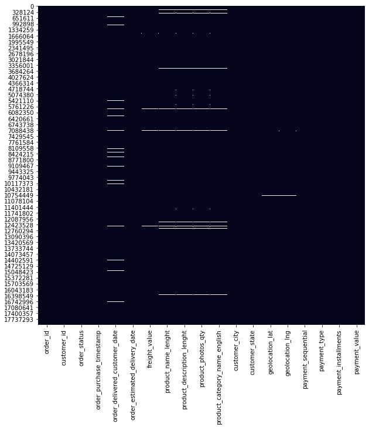

```python
import matplotlib.pyplot as plt
import seaborn as sns

fig, ax = plt.subplots(figsize=(10,10))

sns.heatmap(olist_orders_merge_droppedcol.isnull(), cbar=False)
```

From this heatmap of missing values, we noticed that the missing values are distributed evenly, meaning it is missing completely at random.

Here we decided to drop the rows with missing values since we have a large dataset. This is a commonly used approach to handle null values. This method is also more preferred since complete removal of data with missing values could result in robust and highly accurate model.

```python
olist_orders_merge_dropna = olist_orders_merge_droppedcol.dropna()
olist_orders_merge_dropna
```

|  | order_id | customer_id | order_status | order_purchase_timestamp | order_delivered_customer_date | order_estimated_delivery_date | freight_value | product_name_lenght | product_description_lenght | product_photos_qty | product_category_name_english | customer_city | customer_state | geolocation_lat | geolocation_lng | payment_sequential | payment_type | payment_installments | payment_value |
| --- | --- | --- | --- | --- | --- | --- | --- | --- | --- | --- | --- | --- | --- | --- | --- | --- | --- | --- | --- |
| 0 | e481f51cbdc54678b7cc49136f2d6af7 | 9ef432eb6251297304e76186b10a928d | delivered | 2017-10-02 10:56:33 | 2017-10-10 21:25:13 | 2017-10-18 00:00:00 | 8.72 | 40.0 | 268.0 | 4.0 | housewares | sao paulo | SP | -23.574809 | -46.587471 | 1.0 | credit_card | 1.0 | 18.12 |
| 72 | 53cdb2fc8bc7dce0b6741e2150273451 | b0830fb4747a6c6d20dea0b8c802d7ef | delivered | 2018-07-24 20:41:37 | 2018-08-07 15:27:45 | 2018-08-13 00:00:00 | 22.76 | 29.0 | 178.0 | 1.0 | perfumery | barreiras | BA | -12.169860 | -44.988369 | 1.0 | boleto | 1.0 | 141.46 |
| 91 | 47770eb9100c2d0c44946d9cf07ec65d | 41ce2a54c0b03bf3443c3d931a367089 | delivered | 2018-08-08 08:38:49 | 2018-08-17 18:06:29 | 2018-09-04 00:00:00 | 19.22 | 46.0 | 232.0 | 1.0 | auto | vianopolis | GO | -16.746337 | -48.514624 | 1.0 | credit_card | 3.0 | 179.12 |
| 116 | 949d5b44dbf5de918fe9c16f97b45f8a | f88197465ea7920adcdbec7375364d82 | delivered | 2017-11-18 19:28:06 | 2017-12-02 00:28:42 | 2017-12-15 00:00:00 | 27.20 | 59.0 | 468.0 | 3.0 | pet_shop | sao goncalo do amarante | RN | -5.767733 | -35.275467 | 1.0 | credit_card | 1.0 | 72.20 |
| 134 | ad21c59c0840e6cb83a9ceb5573f8159 | 8ab97904e6daea8866dbdbc4fb7aad2c | delivered | 2018-02-13 21:18:39 | 2018-02-16 18:17:02 | 2018-02-26 00:00:00 | 8.72 | 38.0 | 316.0 | 4.0 | stationery | santo andre | SP | -23.675037 | -46.524784 | 1.0 | credit_card | 1.0 | 28.62 |
| ... | ... | ... | ... | ... | ... | ... | ... | ... | ... | ... | ... | ... | ... | ... | ... | ... | ... | ... | ... |
| 18079294 | 9c5dedf39a927c1b2549525ed64a053c | 39bd1228ee8140590ac3aca26f2dfe00 | delivered | 2017-03-09 09:54:05 | 2017-03-17 15:08:01 | 2017-03-28 00:00:00 | 13.08 | 50.0 | 1517.0 | 1.0 | health_beauty | sao jose dos campos | SP | -23.178732 | -45.889711 | 1.0 | credit_card | 3.0 | 85.08 |
| 18079362 | 63943bddc261676b46f01ca7ac2f7bd8 | 1fca14ff2861355f6e5f14306ff977a7 | delivered | 2018-02-06 12:58:58 | 2018-02-28 17:37:56 | 2018-03-02 00:00:00 | 20.10 | 52.0 | 828.0 | 4.0 | baby | praia grande | SP | -24.001467 | -46.446355 | 1.0 | credit_card | 3.0 | 195.00 |
| 18079412 | 83c1379a015df1e13d02aae0204711ab | 1aa71eb042121263aafbe80c1b562c9c | delivered | 2017-08-27 14:46:43 | 2017-09-21 11:24:17 | 2017-09-27 00:00:00 | 65.02 | 51.0 | 500.0 | 2.0 | home_appliances_2 | nova vicosa | BA | -17.891522 | -39.370942 | 1.0 | credit_card | 5.0 | 271.01 |
| 18079442 | 11c177c8e97725db2631073c19f07b62 | b331b74b18dc79bcdf6532d51e1637c1 | delivered | 2018-01-08 21:28:27 | 2018-01-25 23:32:54 | 2018-02-15 00:00:00 | 40.59 | 59.0 | 1893.0 | 1.0 | computers_accessories | japuiba | RJ | -22.555985 | -42.690761 | 1.0 | credit_card | 4.0 | 441.16 |
| 18079496 | 66dea50a8b16d9b4dee7af250b4be1a5 | edb027a75a1449115f6b43211ae02a24 | delivered | 2018-03-08 20:57:30 | 2018-03-16 13:08:30 | 2018-04-03 00:00:00 | 18.36 | 45.0 | 569.0 | 1.0 | health_beauty | lapa | PR | -25.775722 | -49.723981 | 1.0 | debit_card | 1.0 | 86.86 |

94838 rows × 19 columns

```python
olist_orders_merge_dropna.isna().sum()
```

```
order_id                         0
customer_id                      0
order_status                     0
order_purchase_timestamp         0
order_delivered_customer_date    0
order_estimated_delivery_date    0
freight_value                    0
product_name_lenght              0
product_description_lenght       0
product_photos_qty               0
product_category_name_english    0
customer_city                    0
customer_state                   0
geolocation_lat                  0
geolocation_lng                  0
payment_sequential               0
payment_type                     0
payment_installments             0
payment_value                    0
dtype: int64
```

#### Handling Outliers

```python
print(olist_orders_merge_dropna.dtypes)
```

```
order_id                          object
customer_id                       object
order_status                      object
order_purchase_timestamp          object
order_delivered_customer_date     object
order_estimated_delivery_date     object
freight_value                    float64
product_name_lenght              float64
product_description_lenght       float64
product_photos_qty               float64
product_category_name_english     object
customer_city                     object
customer_state                    object
geolocation_lat                  float64
geolocation_lng                  float64
payment_sequential               float64
payment_type                      object
payment_installments             float64
payment_value                    float64
dtype: object
```

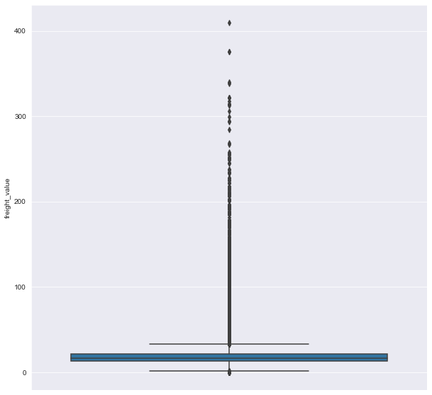

```python
#Plotting the numerical variables with boxplots
import matplotlib.pyplot as plt

sns.set_style("darkgrid")
fig = plt.figure(figsize=(10,10))

sns.boxplot(y='freight_value',data=olist_orders_merge_dropna)
```

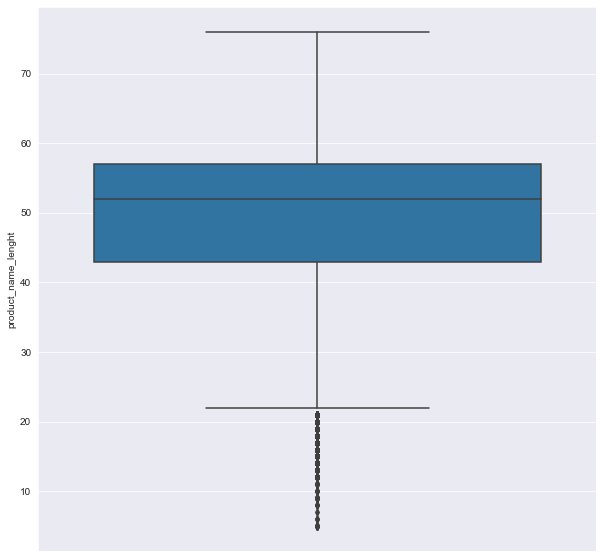

```python
fig = plt.figure(figsize=(10,10))
sns.boxplot(y='product_name_lenght',data=olist_orders_merge_dropna)
```

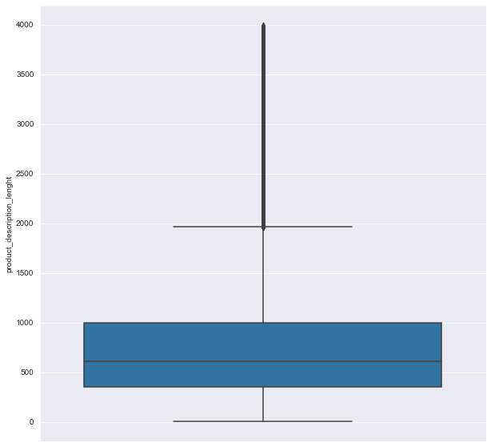

```python
fig = plt.figure(figsize=(10,10))
sns.boxplot(y='product_description_lenght',data=olist_orders_merge_dropna)
```

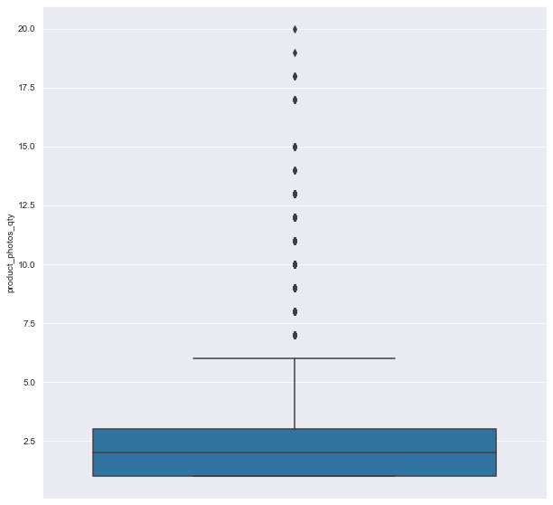

```python
fig = plt.figure(figsize=(10,10))
sns.boxplot(y='product_photos_qty',data=olist_orders_merge_dropna)
```

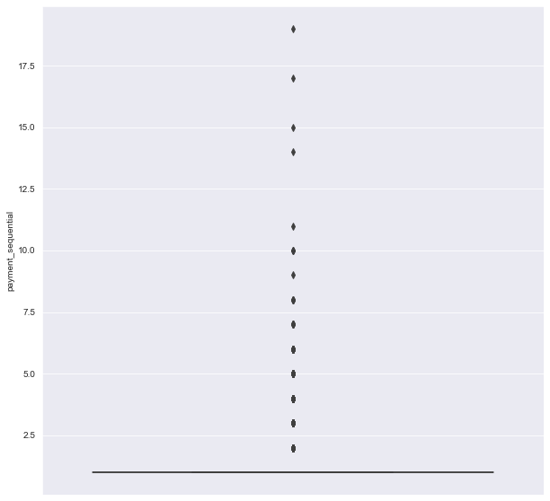

```python
fig = plt.figure(figsize=(10,10))
sns.boxplot(y='payment_sequential',data=olist_orders_merge_dropna)
```

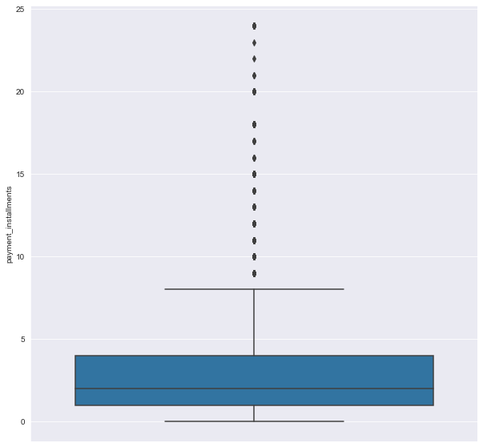

```python
fig = plt.figure(figsize=(10,10))
sns.boxplot(y='payment_installments',data=olist_orders_merge_dropna)
```

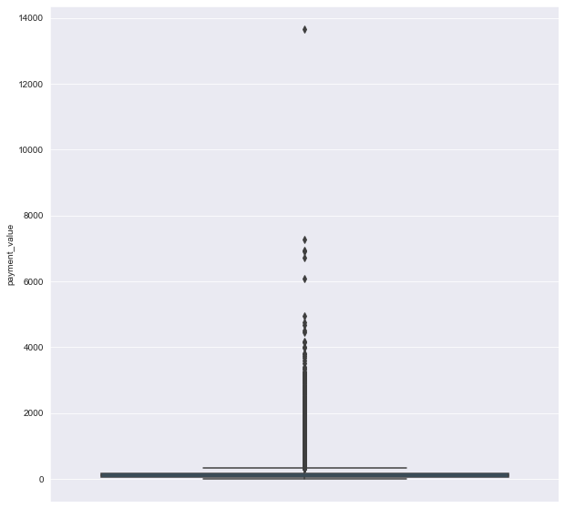

```python
fig = plt.figure(figsize=(10,10))
sns.boxplot(y='payment_value',data=olist_orders_merge_dropna)
```

After visualising the numerical columns with boxplot, we have identified that all the columns contain outliers. However, we have decided not to remove them after inspecting the rows of outliers as removing them might lose interesting findings and useful information. For example, the outliers in 'payment_value' may imply that the e-commerce store has certain VIPs that have very high spending power, the outliers in 'payment_sequential' may help us detect fraud payment etc.

```python
olist_orders_merge_dropna.shape
```

```
(94838, 19)
```

Now, we will inspect the dataset of customer reviews.

```python
#Shape of the dataset
olist_order_reviews.shape
```

```
(100000, 7)
```

```python
#Removing unnecessary columns
olist_order_reviews_droppedcol=olist_order_reviews.drop(['review_creation_date','review_answer_timestamp'],axis=1)
```

```python
print(olist_order_reviews_droppedcol.dtypes)
```

```
review_id                 object
order_id                  object
review_score               int64
review_comment_title      object
review_comment_message    object
dtype: object
```

```python
#Inspecting Missing Values
olist_order_reviews_droppedcol.isnull().sum()
```

```
review_id                     0
order_id                      0
review_score                  0
review_comment_title      88285
review_comment_message    58247
dtype: int64
```

From the data above, we noticed that around 88% of the customers did not give a title to their review and 58% of customers did not leave a comment for their orders.

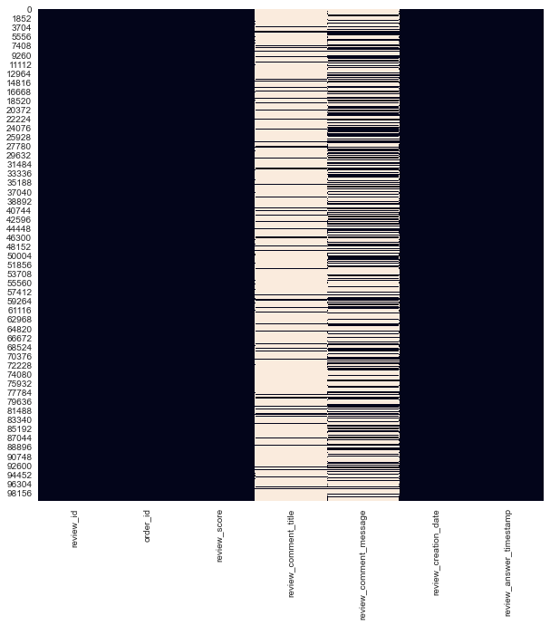

```python
#Visualise the missing values
fig, ax = plt.subplots(figsize=(10,10))

sns.heatmap(olist_order_reviews.isnull(), cbar=False)
```

We can see that the missing values are missing completely at random from the plot because the values are distributed evenly across all orders.

Hence, we will be removing all the rows with no comment because the main purpose of this research paper is to analyse customer reviews and we will then impute the missing values of 'review_comment_title' as empty string.

```python
#Removing rows with missing value in column 'review_comment_message'
olist_order_reviews_dropna = olist_order_reviews.dropna(subset=['review_comment_message'])
olist_order_reviews_dropna.isnull().sum()
```

```
review_id                      0
order_id                       0
review_score                   0
review_comment_title       31767
review_comment_message         0
review_creation_date           0
review_answer_timestamp        0
dtype: int64
```

```python
##Filling in missing values
olist_order_reviews_dropna = olist_order_reviews_dropna.fillna(value='')
olist_order_reviews_dropna.isnull().sum()
```

```
review_id                  0
order_id                   0
review_score               0
review_comment_title       0
review_comment_message     0
review_creation_date       0
review_answer_timestamp    0
dtype: int64
```

```python
olist_order_reviews_dropna.shape
```

```
(41753, 7)
```

```python
#Exporting the dataset to csv file for analysis on tableau
olist_orders_merge_dropna.to_csv('olist_orders_merge_dropna.csv')
```

```python
olist_order_reviews_dropna.to_csv('olist_order_reviews_dropna.csv')
```

## Analysing Customer Reviews

We will be using Python to analyse the customer reviews, specifically the columns 'review_comment_title' and 'review_comment_message' because we would like to use a translation function in Python to translate the reviews from Portugese to English.

```python
import re, nltk
from nltk import word_tokenize
from nltk.corpus import stopwords
from wordcloud import WordCloud, STOPWORDS

#defining stopwords
stop_words = set(stopwords.words('portuguese'))

comments = []

for words in olist_order_reviews_dropna['review_comment_message']:
    only_letters = re.sub("[^a-zA-Z]", " ",words)
    tokens = nltk.word_tokenize(only_letters) #Divide the sentences into smaller parts
    lower_case = [l.lower() for l in tokens] #convert all letters to lower case for consistency
    filtered_result = list(filter(lambda l: l not in stop_words, lower_case))
    comments.append(' '.join(filtered_result))

from collections import Counter
from sklearn.feature_extraction.text import CountVectorizer
from sklearn.feature_extraction.text import TfidfVectorizer

#Translating the text from Portugese to English
from google_trans_new import google_translator
translator = google_translator()
```

#### Analysing text reviews

```python
# Using CountVectorizer to get the most important word
co_1 = CountVectorizer(ngram_range=(1,1))
counts = co_1.fit_transform(comments)
important_word = pd.DataFrame(counts.sum(axis=0),columns=co_1.get_feature_names()).T.sort_values(0,ascending=False).head(50)

# Next, we reset the index, rename the columns and apply the translate module to get the english translations
important_word=important_word.reset_index()
important_word.rename(columns={'index':'word',0:'frequency'},inplace=True)

important_word['english_translation'] = important_word['word'].apply(translator.translate)
important_word
```

|  | word | frequency | english_translation |
| --- | --- | --- | --- |
| 0 | produto | 18866 | product |
| 1 | prazo | 8543 | term |
| 2 | entrega | 6683 | delivery |
| 3 | antes | 5655 | before |
| 4 | chegou | 5643 | has arrived |
| 5 | recebi | 5464 | I received |
| 6 | bom | 4637 | good |
| 7 | recomendo | 4362 | I recommend |
| 8 | entregue | 3899 | delivered |
| 9 | veio | 3362 | came |
| 10 | bem | 3139 | good |
| 11 | comprei | 2884 | I bought |
| 12 | qualidade | 2824 | quality |
| 13 | loja | 2467 | store |
| 14 | ainda | 2403 | still |
| 15 | tudo | 2361 | all |
| 16 | compra | 2292 | purchase |
| 17 | gostei | 1918 | liked it |
| 18 | timo | 1840 | Timo |
| 19 | at | 1832 | at |
| 20 | excelente | 1811 | Excellent |
| 21 | super | 1739 | super |
| 22 | dentro | 1475 | inside |
| 23 | pedido | 1428 | order |
| 24 | pida | 1428 | ask |
| 25 | nao | 1414 | brain |
| 26 | dia | 1386 | day |
| 27 | boa | 1341 | good |
| 28 | lannister | 1331 | lannister |
| 29 | produtos | 1303 | products |
| 30 | est | 1278 | East |
| 31 | site | 1230 | site |
| 32 | pois | 1128 | because |
| 33 | ser | 1096 | to be |
| 34 | pido | 1007 | I ask |
| 35 | sempre | 997 | always |
| 36 | perfeito | 975 | Perfect |
| 37 | agora | 964 | now |
| 38 | parab | 953 | I can |
| 39 | ns | 952 | ns |
| 40 | dias | 949 | days |
| 41 | certo | 937 | of course |
| 42 | comprar | 936 | to buy |
| 43 | tima | 914 | team |
| 44 | conforme | 903 | according |
| 45 | pra | 903 | for |
| 46 | vel | 888 | vel |
| 47 | previsto | 868 | planned |
| 48 | es | 861 | is |
| 49 | apenas | 858 | only |

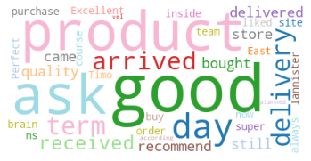

```python
#Visualizing with Wordcloud
wordcloud1 = WordCloud(colormap="tab20", background_color='white',max_words=100).generate(' '.join(important_word['english_translation']))
plt.axis('off')
plt.imshow(wordcloud1)
```

```python
# Using CountVectorizer to get the most important 2-gram
co_2 = CountVectorizer(ngram_range=(2,2))
counts = co_2.fit_transform(comments)
important_2_gram = pd.DataFrame(counts.sum(axis=0),columns=co_2.get_feature_names()).T.sort_values(0,ascending=False).head(50)

# Next, we reset the index, rename the columns and apply the translate module to get the english translations
important_2_gram=important_2_gram.reset_index()
important_2_gram.rename(columns={'index':'2-gram',0:'frequency'},inplace=True)

important_2_gram['english_translation'] = important_2_gram['2-gram'].apply(translator.translate)
important_2_gram
```

|  | 2-gram | frequency | english_translation |
| --- | --- | --- | --- |
| 0 | antes prazo | 4207 | before deadline |
| 1 | recebi produto | 1942 | I received product |
| 2 | produto chegou | 1720 | product arrived |
| 3 | produto entregue | 1616 | product delivered |
| 4 | chegou antes | 1465 | arrived before |
| 5 | dentro prazo | 1092 | within term |
| 6 | bem antes | 973 | well before |
| 7 | parab ns | 950 | parab ns |
| 8 | entrega pida | 900 | delivery ask |
| 9 | produto bom | 883 | good product |
| 10 | produto veio | 775 | product came |
| 11 | entregue antes | 732 | delivered before |
| 12 | prazo entrega | 684 | delivery time |
| 13 | bem embalado | 654 | well packed |
| 14 | timo produto | 613 | great product |
| 15 | super recomendo | 608 | super recommend |
| 16 | chegou bem | 551 | arrived well |
| 17 | entrega antes | 534 | delivery before |
| 18 | tudo certo | 525 | all right |
| 19 | at agora | 523 | until now |
| 20 | tima qualidade | 503 | great quality |
| 21 | rel gio | 491 | rel thu |
| 22 | ainda recebi | 488 | I still received |
| 23 | boa qualidade | 475 | good quality |
| 24 | entregue prazo | 470 | deliver deadline |
| 25 | prazo produto | 453 | product term |
| 26 | bom produto | 445 | good product |
| 27 | chegou prazo | 430 | arrived deadline |
| 28 | entrega super | 405 | super delivery |
| 29 | produto excelente | 396 | excellent product |
| 30 | nota fiscal | 394 | tax note |
| 31 | produto qualidade | 385 | product quality |
| 32 | gostei produto | 378 | liked product |
| 33 | antes data | 365 | before date |
| 34 | prazo previsto | 359 | expected deadline |
| 35 | antes previsto | 347 | previously planned |
| 36 | tudo ok | 347 | everything is OK |
| 37 | entrega produto | 343 | product delivery |
| 38 | at momento | 332 | at momento |
| 39 | entrega prazo | 329 | delivery time |
| 40 | condi es | 326 | condi is |
| 41 | produto ainda | 320 | product yet |
| 42 | perfeito estado | 319 | perfect state |
| 43 | super pida | 312 | super ask |
| 44 | lojas lannister | 303 | lannister stores |
| 45 | recomendo loja | 299 | recommend shop |
| 46 | comprei produto | 297 | bought product |
| 47 | produto entrega | 295 | product delivery |
| 48 | excelente produto | 294 | excellent product |
| 49 | prazo recomendo | 294 | term recommend |

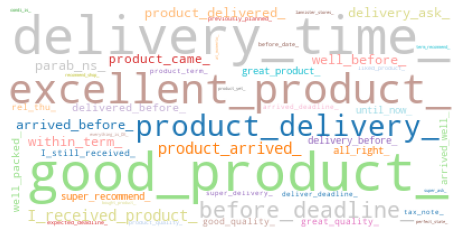

```python
#Visualizing with Wordcloud
wordcloud2 = WordCloud(colormap="tab20", background_color='white',max_words=200).generate(";".join(important_2_gram['english_translation']).replace(" ", "_"))
plt.figure(figsize=(8, 5))
plt.imshow(wordcloud2)
plt.axis("off")
plt.show()
```

```python
# Using CountVectorizer to get the most important 3-gram
co_3 = CountVectorizer(ngram_range=(3,3))
counts = co_3.fit_transform(comments)
important_3_gram = pd.DataFrame(counts.sum(axis=0),columns=co_3.get_feature_names()).T.sort_values(0,ascending=False).head(30)

# Next, we reset the index, rename the columns and apply the translate module to get the english translations
important_3_gram=important_3_gram.reset_index()
important_3_gram.rename(columns={'index':'3-gram',0:'frequency'},inplace=True)

important_3_gram['english_translation'] = important_3_gram['3-gram'].apply(translator.translate)
important_3_gram
```

|  | 3-gram | frequency | english_translation |
| --- | --- | --- | --- |
| 0 | chegou antes prazo | 1112 | arrived before deadline |
| 1 | bem antes prazo | 708 | well before term |
| 2 | entregue antes prazo | 608 | delivered before deadline |
| 3 | produto chegou antes | 448 | product arrived before |
| 4 | entrega antes prazo | 433 | delivery before deadline |
| 5 | chegou bem antes | 417 | arrived well before |
| 6 | produto entregue antes | 374 | product delivered before |
| 7 | entrega super pida | 297 | super delivery ask |
| 8 | antes prazo previsto | 287 | before expected deadline |
| 9 | ainda recebi produto | 261 | I still received product |
| 10 | produto tima qualidade | 257 | great quality product |
| 11 | produto boa qualidade | 234 | good quality product |
| 12 | entregue dentro prazo | 230 | delivered on time |
| 13 | produto entregue prazo | 228 | product delivered on time |
| 14 | antes prazo produto | 227 | before product term |
| 15 | antes data prevista | 218 | before expected date |
| 16 | recebi antes prazo | 200 | I received before deadline |
| 17 | perfeitas condi es | 199 | perfect conditions |
| 18 | antes prazo recomendo | 189 | before deadline recommend |
| 19 | est parab ns | 185 | is parab ns |
| 20 | chegou dentro prazo | 183 | arrived on time |
| 21 | antes prazo estipulado | 180 | before deadline |
| 22 | entrega pida produto | 168 | delivery order product |
| 23 | produto chegou prazo | 165 | product arrived deadline |
| 24 | entrega dentro prazo | 164 | on-time delivery |
| 25 | produto chegou bem | 163 | product arrived well |
| 26 | nao recebi produto | 148 | I did not recieve the product |
| 27 | recebi produto antes | 130 | I received product before |
| 28 | produto entregue dentro | 129 | product delivered within |
| 29 | entregue bem antes | 128 | deliver well before |

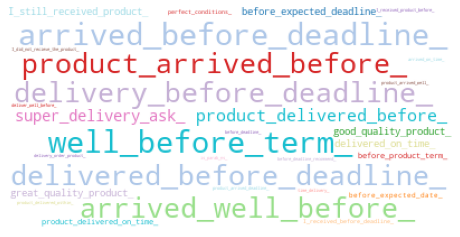

```python
#Visualizing with Wordcloud
wordcloud3 = WordCloud(colormap="tab20", background_color='white',max_words=200).generate(";".join(important_3_gram['english_translation']).replace(" ", "_"))
plt.figure(figsize=(8, 5))
plt.imshow(wordcloud3)
plt.axis("off")
plt.show()
```

#### Analysing review titles

```python
comments_titles = []

for words in review_data_title:
    only_letters = re.sub("[^a-zA-Z]", " ",words)
    tokens = nltk.word_tokenize(only_letters)
    lower_case = [l.lower() for l in tokens]
    filtered_result = list(filter(lambda l: l not in stop_words, lower_case))

    comments_titles.append(' '.join(filtered_result))
```

```python
# Using CountVectorizer to get the most important word
co_1 = CountVectorizer(ngram_range=(1,1))
counts = co_1.fit_transform(comments_titles)
important_word_title = pd.DataFrame(counts.sum(axis=0),columns=co_1.get_feature_names()).T.sort_values(0,ascending=False).head(50)

# Next, we reset the index, rename the columns and apply the translate module to get the english translations
important_word_title=important_word_title.reset_index()
important_word_title.rename(columns={'index':'word',0:'frequency'},inplace=True)

important_word_title['english_translation'] = important_word_title['word'].apply(translator.translate)
important_word_title
```

|  | word | frequency | english_translation |
| --- | --- | --- | --- |
| 0 | recomendo | 2085 | I recommend |
| 1 | produto | 1327 | product |
| 2 | bom | 1321 | good |
| 3 | super | 901 | super |
| 4 | timo | 730 | Timo |
| 5 | excelente | 665 | Excellent |
| 6 | entrega | 544 | delivery |
| 7 | otimo | 369 | great |
| 8 | recebi | 302 | I received |
| 9 | boa | 273 | good |
| 10 | tima | 218 | team |
| 11 | tudo | 192 | all |
| 12 | entregue | 183 | delivered |
| 13 | recomendado | 180 | recommended |
| 14 | ok | 158 | ok |
| 15 | compra | 152 | purchase |
| 16 | prazo | 150 | term |
| 17 | loja | 133 | store |
| 18 | pida | 132 | ask |
| 19 | perfeito | 132 | Perfect |
| 20 | chegou | 126 | has arrived |
| 21 | nao | 117 | brain |
| 22 | nota | 111 | note |
| 23 | ruim | 108 | spacious |
| 24 | errado | 108 | wrong |
| 25 | gostei | 105 | liked it |
| 26 | qualidade | 100 | quality |
| 27 | satisfeito | 90 | pleased |
| 28 | certo | 87 | of course |
| 29 | veio | 86 | came |
| 30 | ssimo | 80 | ssimo |
| 31 | defeito | 78 | defect |
| 32 | otima | 76 | great |
| 33 | ainda | 75 | still |
| 34 | pedido | 71 | order |
| 35 | vel | 68 | vel |
| 36 | satisfeita | 67 | satisfied |
| 37 | antes | 65 | before |
| 38 | top | 64 | top |
| 39 | pido | 55 | I ask |
| 40 | sim | 53 | sim |
| 41 | amei | 53 | Amei |
| 42 | atendimento | 52 | attendance |
| 43 | ssima | 52 | ssima |
| 44 | falta | 51 | lack |
| 45 | vendedor | 50 | salesman |
| 46 | diferente | 50 | different |
| 47 | rel | 47 | rel |
| 48 | gio | 47 | gio |
| 49 | faltando | 46 | missing |

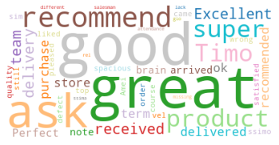

```python
#Visualizing with Wordcloud
wordcloud4 = WordCloud(colormap="tab20", background_color='white',max_words=100).generate(' '.join(important_word_title['english_translation']))
plt.axis('off')
plt.imshow(wordcloud4)
```

```python
# Using CountVectorizer to get the most important 2-gram
co_2 = CountVectorizer(ngram_range=(2,2))
counts = co_2.fit_transform(comments_titles)
important_2_gram_title = pd.DataFrame(counts.sum(axis=0),columns=co_2.get_feature_names()).T.sort_values(0,ascending=False).head(50)

# Next, we reset the index, rename the columns and apply the translate module to get the english translations
important_2_gram_title=important_2_gram_title.reset_index()
important_2_gram_title.rename(columns={'index':'2-gram',0:'frequency'},inplace=True)

important_2_gram_title['english_translation'] = important_2_gram_title['2-gram'].apply(translator.translate)
important_2_gram_title
```

|  | 2-gram | frequency | english_translation |
| --- | --- | --- | --- |
| 0 | super recomendo | 681 | super recommend |
| 1 | recebi produto | 131 | I received product |
| 2 | timo produto | 103 | great product |
| 3 | super recomendado | 103 | super recommended |
| 4 | produto entregue | 103 | product delivered |
| 5 | entrega pida | 92 | delivery ask |
| 6 | bom produto | 76 | good product |
| 7 | tudo certo | 76 | all right |
| 8 | produto errado | 74 | wrong product |
| 9 | produto bom | 66 | good product |
| 10 | produto defeito | 51 | defect product |
| 11 | antes prazo | 48 | before deadline |
| 12 | rel gio | 46 | rel thu |
| 13 | tudo ok | 45 | everything is OK |
| 14 | parab ns | 38 | parab ns |
| 15 | excelente produto | 37 | excellent product |
| 16 | produto veio | 36 | product came |
| 17 | entrega super | 33 | super delivery |
| 18 | super pida | 30 | super ask |
| 19 | produto diferente | 28 | different product |
| 20 | nao recebi | 27 | not received |
| 21 | otimo produto | 27 | great product |
| 22 | entrega rapida | 26 | fast delivery |
| 23 | atraso entrega | 26 | delivery delay |
| 24 | produto excelente | 25 | excellent product |
| 25 | nao recomendo | 25 | I do not recommend |
| 26 | confi vel | 23 | trust or |
| 27 | ainda recebi | 23 | I still received |
| 28 | tima loja | 21 | great store |
| 29 | produto chegou | 21 | product arrived |
| 30 | entrega prazo | 21 | delivery time |
| 31 | recomendo loja | 21 | recommend shop |
| 32 | boa compra | 21 | good bargain |
| 33 | tima compra | 20 | great purchase |
| 34 | recomendo sim | 20 | yes I recommend |
| 35 | entrega incompleta | 19 | incomplete delivery |
| 36 | recomendo todos | 18 | recommend all |
| 37 | chegou antes | 18 | arrived before |
| 38 | entrega antes | 17 | delivery before |
| 39 | produto qualidade | 17 | product quality |
| 40 | excelente compra | 17 | excellent buy |
| 41 | produto recebido | 16 | product received |
| 42 | demora entrega | 16 | delay delivery |
| 43 | produto ok | 16 | ok product |
| 44 | boa loja | 16 | good store |
| 45 | nao entregue | 15 | not delivered |
| 46 | entregue prazo | 15 | deliver deadline |
| 47 | pedido incompleto | 15 | incomplete order |
| 48 | tudo perfeito | 14 | everything perfect |
| 49 | boa qualidade | 14 | good quality |

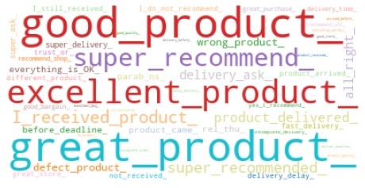

```python
#Visualizing with Wordcloud
wordcloud5 = WordCloud(colormap="tab20", background_color='white',max_words=200).generate(";".join(important_2_gram_title['english_translation']).replace(" ", "_"))
plt.figure(figsize=(8, 5))
plt.imshow(wordcloud5)
plt.axis("off")
plt.show()
```

```python
# Using CountVectorizer to get the most important 3-gram
co_3 = CountVectorizer(ngram_range=(3,3))
counts = co_3.fit_transform(comments_titles)
important_3_gram_title = pd.DataFrame(counts.sum(axis=0),columns=co_3.get_feature_names()).T.sort_values(0,ascending=False).head(50)

# Next, we reset the index, rename the columns and apply the translate module to get the english translations
important_3_gram_title=important_3_gram_title.reset_index()
important_3_gram_title.rename(columns={'index':'3-gram',0:'frequency'},inplace=True)

important_3_gram_title['english_translation'] = important_3_gram_title['3-gram'].apply(translator.translate)
important_3_gram_title
```

|  | 3-gram | frequency | english_translation |
| --- | --- | --- | --- |
| 0 | entrega super pida | 27 | super delivery ask |
| 1 | entrega antes prazo | 15 | delivery before deadline |
| 2 | custo benef cio | 12 | cost benefit |
| 3 | chegou antes prazo | 11 | arrived before deadline |
| 4 | nao recebi produto | 11 | I did not recieve the product |
| 5 | produto boa qualidade | 8 | good quality product |
| 6 | produto entregue prazo | 8 | product delivered on time |
| 7 | produto veio errado | 7 | product came wrong |
| 8 | produto veio defeito | 7 | product came defect |
| 9 | produto nao entregue | 7 | product not delivered |
| 10 | ainda recebi produt | 6 | I still received prod |
| 11 | entrega super rapida | 6 | Super fast delivery |
| 12 | ainda nao recebi | 6 | I haven't received it yet |
| 13 | produto diferente foto | 5 | different product photo |
| 14 | rel gio casio | 5 | rel gio casio |
| 15 | produto ainda chegou | 5 | product still arrived |
| 16 | recebi produto errado | 5 | I received wrong product |
| 17 | entregue antes prazo | 5 | delivered before deadline |
| 18 | entrega dentro prazo | 5 | on-time delivery |
| 19 | produto entregue errado | 5 | wrong delivered product |
| 20 | loja confi vel | 4 | reliable store |
| 21 | timo custo benef | 4 | great cost benefit |
| 22 | bom neg cio | 4 | good deal |
| 23 | recebi antes prazo | 4 | I received before deadline |
| 24 | produto veio diferente | 4 | product came different |
| 25 | bem antes prazo | 4 | well before term |
| 26 | recomendo restri es | 4 | recommend restrictions |
| 27 | timo custo beneficio | 4 | fear cost benefit |
| 28 | bom custo benef | 4 | good cost benefit |
| 29 | recebi produto diferente | 3 | I received different product |
| 30 | produto veio quebrado | 3 | product came broken |
| 31 | nao recebi produt | 3 | I didn't receive prod |
| 32 | produto baixa qualidad | 3 | low quality product |
| 33 | boa compra recomendo | 3 | good buy recommend |
| 34 | tudo conforme combinado | 3 | everything as agreed |
| 35 | lindo rel gio | 3 | lindo rel gio |
| 36 | bom rel gio | 3 | good watch |
| 37 | entrega faltando produto | 3 | delivery missing product |
| 38 | recebi todos produ | 3 | I received all products |
| 39 | rel gio bom | 3 | good watch |
| 40 | produto nao chegou | 3 | product has not arrived |
| 41 | produto ssima qualid | 3 | very good product |
| 42 | chegou bem antes | 3 | arrived well before |
| 43 | carteira couro marrom | 3 | brown leather wallet |
| 44 | recebi produto cert | 3 | I received cert product |
| 45 | rel gio falso | 3 | fake relay |
| 46 | posso avaliar ainda | 3 | I can evaluate yet |
| 47 | poderia ser melhor | 3 | could be better |
| 48 | produto mal embalado | 3 | poorly packaged product |
| 49 | lugar pra comprar | 2 | place to buy |

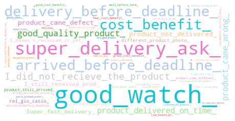

```python
#Visualizing with Wordcloud
wordcloud6 = WordCloud(colormap="tab20", background_color='white',max_words=200).generate(";".join(important_3_gram_title['english_translation']).replace(" ", "_"))
plt.figure(figsize=(8, 5))
plt.imshow(wordcloud6)
plt.axis("off")
plt.show()
```

### Sentiment Analysis

We will be mapping the ratings to 1 = Positive Review for review_score >3 and 0 = Negative Review for review_score<3 and removing neutral reviews (review_score=3).

```python
# Mapping the ratings
olist_order_reviews_dropna['Sentiment_rating'] = np.where(olist_order_reviews_dropna.review_score > 3,1,0)

# Removing neutral reviews
olist_order_reviews_dropna = olist_order_reviews_dropna[olist_order_reviews_dropna.review_score != 3]

# Printing the counts of each class
olist_order_reviews_dropna['Sentiment_rating'].value_counts()
```

```
1    26680
0    11408
Name: Sentiment_rating, dtype: int64
```

70% of sentiments are classified as positive and 30% of sentiments are classified as negative

```python
olist_order_reviews_dropna.head(10)
```

[output not shown]

```python
from sklearn.model_selection import train_test_split
from sklearn.linear_model import LogisticRegression
```

```python
comments =[]

stop_words = set(stopwords.words('portuguese'))

for words in olist_order_reviews_dropna['review_comment_message']:
    only_letters = re.sub("[^a-zA-Z]", " ",words)
    tokens = nltk.word_tokenize(only_letters) #Divide the sentences into smaller parts
    lower_case = [l.lower() for l in tokens] #convert all letters to lower case for consistency
    filtered_result = list(filter(lambda l: l not in stop_words, lower_case))
    comments.append(' '.join(filtered_result))

count_vect = CountVectorizer(stop_words =set(stopwords.words('portuguese')),
                             ngram_range=(1,4))

count_vect_comments = count_vect.fit_transform(comments)
count_vect_comments
```

```
<38088x422326 sparse matrix of type '<class 'numpy.int64'>'
	with 870129 stored elements in Compressed Sparse Row format>
```

```python
#Split the dataset into training and testing dataset
X_train, X_test, y_train, y_test= train_test_split(count_vect_comments,
                                                                    olist_order_reviews_dropna['Sentiment_rating'],
                                                                    test_size = 0.3,
                                                                    random_state = 42)
```

```python
y_test.value_counts()/y_test.shape[0]
```

```
1    0.698434
0    0.301566
Name: Sentiment_rating, dtype: float64
```

69.8% of sentiments are classified as positive and 30.2% of sentiments are classified as negative

#### Logistic Regression

```python
from sklearn.linear_model import LogisticRegression
from sklearn.metrics import f1_score
```

```python
# Defining and training the model
lr = LogisticRegression(max_iter=150)
lr.fit(X_train, y_train)

# Predicting the results
test_pred = lr.predict(X_test)

print("F1 score: ", f1_score(y_test,test_pred))
```

```
F1 score:  0.9410299520518088
```

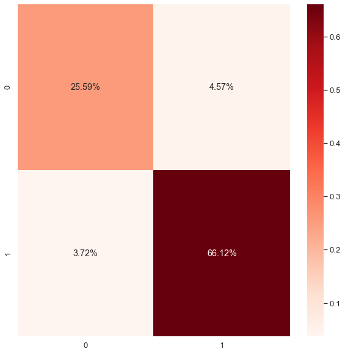

```python
#predicted values of Y labels
pred_train = lr.predict(X_train)
pred_test = lr.predict(X_test)

from sklearn.metrics import confusion_matrix

cf = confusion_matrix(y_test,pred_test)

#plot confusion matrix
plt.figure(figsize=(10,10))
sns.heatmap(cf/np.sum(cf), annot=True,fmt='.2%', cmap='Reds')
plt.show()
```

#### Top 20 Most important words with Positive sentiments

```python
lr_weights = pd.DataFrame(list(zip(count_vect.get_feature_names(),
                                   lr.coef_[0])),
                          columns= ['words','weights'])

Positive_sentiments = pd.DataFrame(lr_weights.sort_values(['weights'], ascending = False)[:20])
```

```python
Positive_sentiments['english_translation'] = Positive_sentiments['words'].apply(translator.translate)
Positive_sentiments
```

|  | words | weights | english_translation |
| --- | --- | --- | --- |
| 166120 | excelente | 3.256390 | Excellent |
| 389525 | timo | 3.172105 | Timo |
| 275765 | pido | 2.694402 | I ask |
| 255753 | otimo | 2.595993 | great |
| 17056 | amei | 2.497577 | Amei |
| 358938 | satisfeito | 2.446504 | pleased |
| 274716 | pida | 2.442544 | ask |
| 272397 | perfeito | 2.415608 | Perfect |
| 5972 | adorei | 2.352800 | I loved it |
| 215217 | lindo | 2.319936 | pretty |
| 45931 | bom | 2.318323 | good |
| 255509 | otima | 2.099878 | great |
| 388676 | tima | 2.055728 | team |
| 358400 | satisfeita | 1.914937 | satisfied |
| 250613 | obrigada | 1.884093 | thanks |
| 252397 | ok | 1.859842 | ok |
| 62098 | certinho | 1.834610 | just right |
| 100770 | corretamente | 1.809469 | correctly |
| 19700 | antes | 1.807287 | before |
| 43939 | boa | 1.789176 | good |

```python
#### Top 20 Most important words with Negative sentiments
```

```python
Negative_Sentiments = pd.DataFrame(lr_weights.sort_values(['weights'], ascending = False)[-20:])
Negative_Sentiments['english_translation'] = Negative_Sentiments['words'].apply(translator.translate)
Negative_Sentiments
```

|  | words | weights | english_translation |
| --- | --- | --- | --- |
| 153098 | enviaram | -1.486480 | sent |
| 264666 | passou | -1.490242 | passed on |
| 34507 | atrasada | -1.490712 | late |
| 34716 | atraso | -1.499405 | delay |
| 145766 | entregar | -1.506367 | deliver |
| 107399 | decepcionada | -1.514798 | disappointed |
| 123147 | diferente | -1.515167 | different |
| 336270 | recebi | -1.520174 | I received |
| 239539 | nao | -1.529595 | brain |
| 274020 | pessima | -1.533274 | very bad |
| 109952 | demora | -1.619071 | delay |
| 146251 | entregaram | -1.643342 | delivered |
| 9723 | aguardando | -1.712272 | waiting |
| 329667 | quebrado | -1.765645 | broke |
| 203233 | insatisfeita | -1.805251 | unsatisfied |
| 274092 | pessimo | -1.831116 | bad |
| 374973 | ssima | -1.931481 | ssima |
| 201265 | inferior | -2.114481 | lower |
| 375319 | ssimo | -2.386278 | ssimo |
| 355636 | ruim | -2.745180 | spacious |

#### Naive Bayes

```python
from sklearn.naive_bayes import MultinomialNB
from sklearn.model_selection import train_test_split,GridSearchCV
```

```python
multinb = MultinomialNB(class_prior=[0.25,0.5])
multinb.fit(X_train, y_train)
param = {'alpha': [1]}

NB = GridSearchCV(multinb, param, cv=2,refit=False,return_train_score=True,scoring='roc_auc')
NB.fit(X_train, y_train)
```

```
GridSearchCV(cv=2, estimator=MultinomialNB(class_prior=[0.25, 0.5]),
             param_grid={'alpha': [1]}, refit=False, return_train_score=True,
             scoring='roc_auc')
```

```python
clf = MultinomialNB(alpha=1 ,class_prior=[0.25,0.5])
clf.fit(X_train, y_train)

#predicted value of y probabilities
y_pred_train = multinb.predict_proba(X_train)
y_pred_test = multinb.predict_proba(X_test)

#predicted values of Y labels
pred_label_train = multinb.predict(X_train)
pred_label_test = multinb.predict(X_test)
```

```python
#Get the weights of the words
nb_weights = pd.DataFrame(list(zip(count_vect.get_feature_names(),
                                   multinb.coef_[0])),
                          columns= ['words','weights'])
```

```python
Positive_sentiments = pd.DataFrame(lr_weights.sort_values(['weights'], ascending = False)[:20])
```

```python
Positive_sentiments['english_translation'] = Positive_sentiments['words'].apply(translator.translate)
Positive_sentiments
```

|  | words | weights | english_translation |
| --- | --- | --- | --- |
| 166120 | excelente | 3.256390 | Excellent |
| 389525 | timo | 3.172105 | Timo |
| 275765 | pido | 2.694402 | I ask |
| 255753 | otimo | 2.595993 | great |
| 17056 | amei | 2.497577 | Amei |
| 358938 | satisfeito | 2.446504 | pleased |
| 274716 | pida | 2.442544 | ask |
| 272397 | perfeito | 2.415608 | Perfect |
| 5972 | adorei | 2.352800 | I loved it |
| 215217 | lindo | 2.319936 | pretty |
| 45931 | bom | 2.318323 | good |
| 255509 | otima | 2.099878 | great |
| 388676 | tima | 2.055728 | team |
| 358400 | satisfeita | 1.914937 | satisfied |
| 250613 | obrigada | 1.884093 | thanks |
| 252397 | ok | 1.859842 | ok |
| 62098 | certinho | 1.834610 | just right |
| 100770 | corretamente | 1.809469 | correctly |
| 19700 | antes | 1.807287 | before |
| 43939 | boa | 1.789176 | good |

```python
Negative_Sentiments = pd.DataFrame(nb_weights.sort_values(['weights'], ascending = False)[-20:])
```

```python
Negative_Sentiments['english_translation'] = Negative_Sentiments['words'].apply(translator.translate)
Negative_Sentiments
```

|  | words | weights | english_translation |
| --- | --- | --- | --- |
| 173699 | faz comprei nada | -13.544145 | do I bought nothing |
| 173722 | faz dias comprei jeito | -13.544145 | days ago I bought way |
| 173713 | faz dias ainda chegou | -13.544145 | it's been days yet |
| 173721 | faz dias comprei at | -13.544145 | days ago I bought at |
| 173720 | faz dias comprei agora | -13.544145 | I bought it now |
| 173718 | faz dias compra at | -13.544145 | days ago buy at |
| 173717 | faz dias compra | -13.544145 | days ago buy |
| 173716 | faz dias chegou produto | -13.544145 | days ago product arrived |
| 173715 | faz dias chegou local | -13.544145 | days ago arrived local |
| 173714 | faz dias chegou | -13.544145 | days ago arrived |
| 173712 | faz dias ainda | -13.544145 | days ago |
| 173700 | faz comprei nada enviar | -13.544145 | does bought nothing send |
| 173710 | faz data compra esperando | -13.544145 | makes purchase date waiting |
| 173709 | faz data compra | -13.544145 | make purchase date |
| 173708 | faz data | -13.544145 | makes a date |
| 173704 | faz comprei site ate | -13.544145 | do bought site until |
| 173703 | faz comprei site | -13.544145 | do bought site |
| 173702 | faz comprei produto entregue | -13.544145 | makes bought product delivered |
| 173701 | faz comprei produto | -13.544145 | do bought product |
| 422325 | zxdad | -13.544145 | zxdad |

```python
cf_matrix_test = confusion_matrix(y_test,pred_label_test)
```

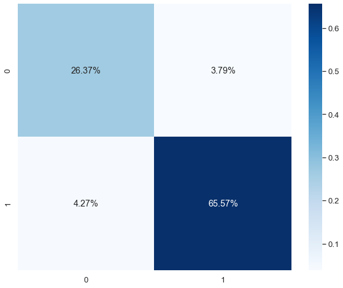

```python
#plot confusion matrix
plt.figure(figsize=(10,8))
sns.heatmap(cf_matrix_test/np.sum(cf_matrix_test), annot=True,fmt='.2%', cmap='Blues')
plt.show()
```